# Data Structures and Algorithms Notes

# Lecture 7: Dijkstra's Algorithm for Shortest Paths (24/02/2026)

## Live Class

- Learning Outcomes:
  - Translate a real-world problem into a weighted directed graph (nodes, edges, and what the edge weights mean)
  - Formally state the shortest path problem and interpret the output (distances and the actual path)
  - Explain when BFS is enough (unweighted / unit weight edges) and when we need Dijkstra (non-negative edge weights)
  - Run Dijkstra's algorithm by hand on a small graph, using the idea of relaxation and a priority queue
  - Implement Dijkstra in code, and reconstruct the shortest path
  - Recognize common pitfalls and limits: negative edge weights break Dijkstra (you need a different algorithm, e.g. Bellman-Ford)
- On average, your friends have mmore friends than you
  - Form of sampling bias
  - People with more friends are likelier to be your friend
    - Can efficiently monitor outbreaks of new diseases by just monitoring superspreaders ("central friends")
    - Same technique can spread new ideas (political campaign)
- Shortest-path problems arise whenever we model choices as transitions between states with a cost
  - Supply Chain: route planning for deliveries, warehouse picking routes, production logistics (minimize time, fuel, penalty costs)
  - FinTech: cheapest path for cross-border payments through correspondent banks/payment rails
  - Trading & Market Microstructure: simplified models of smart order routing/best execution as a path through venues with costs
  - Risks & Networks: shortest-path distance as building blocks for network measures (e.g. closeness) and for understanding how "close" institutions or sectors are in a financial network
  - Data Science: graph-based features and subroutines (e.g. as a component inside A* search or other graph methods)

### Dijkstra's Algorithm v.1

- Dijkstra's algorithm v.1
  - Input: graph $G$, start node $s$
  - Output: shortest distances (and paths) from $s$ to all other nodes in $G$
  - Initialization: mark $s$ explored and set its distance to 0
    - Other nodes are unexplored and have no distances
  - Main Loop: while there are unexplored nodes
    - Find "costs" of all edges from expored nodes to unexplored nodes
    - Pick the "cheapest" such edge, mark its end node explored and store its cost as its distance
  - Find the shortest paths
    - The stored distances will be the shortest distances from $s$
- Look at slides for visual example
- Proof by Induction of Dijkstra finding the shortest path
  - Claim: in the first iteration, we find the shortest distance to the first node we explore
    - The lowest-cost edge from explored (start node) to unexplored (any other node) must be the shortest distance to that node
  - Assume that in the $n$th iteration, the result is also true
  - For the $n+1$th iteration, we will use proof by contradiction
    - Cheapest path in this iteration is $s \rightarrow \dots \rightarrow x \rightarrow y$
      - This means that the edge $x \rightarrow y$ has the lowest Dijkstra score crossing the boundary between explored and unexplored nodes
    - Suppose there is an alternative cheaper path $s \rightarrow \dots \rightarrow z \rightarrow v \rightarrow w \rightarrow \dots \rightarrow y$ where $w$ is an unexplored node
      - This still crosses the boundary between explored and unexplored nodes
      - But we saw that $x \rightarrow y$ is the cheapeast way to cross the boundary
      - Therefore $s \rightarrow \dots \rightarrow z \rightarrow v$ has a higher cost than $s \rightarrow \dots \rightarrow x \rightarrow y$
  - By proof by induction, we have proven that Dijkstra found the shortest path
- Formal Definition
  - Input: (directed, connected) graph $G = (V,E)$
    - $V$: set of $n$ vertices, $E$: set of $m$ edges
    - Each edge $e$ has length (cost) $c_e \ge 0$
      - This is an important prerequisite
    - Start from vertex $s$
  - Output: for each vertex $v$ in $V$:
    - Length of shortest $s \rightarrow v$ path in $G$
- For a graph $G=(V,E)$: $V$: set of $n$ vertices, $E$: set of $m$ edges, edge $(v,w)$ has length $c_{vw}$
  - Initialize: starting vertex $s$
    - Set of vertices gone through so far $X = \{s\}$ (not gone through $V-X$)
    - Shortest distances to all vertices $A$: $A[s]=0$
  - Main loop: While $X \neq V$ (not all nodes explored):
    - Go through all edges $(v,w)$ starting in $X$ and ending in $V-X$
    - Pick the edge that minimizes $A[v]+c_{vw}$, call it $(v^*,w^*)$
    - Add vertex $w^*$ to $X$ and set $A[w^*] = A[v^*] +c_{v^*w^*}$
- Running time: $O(mn)$
  - Iterations of while loop: $n-1$
  - Work per iteration: $O(m)$

### [Non-Examinable] How to make Dijkstra's Algorithm Efficient

- Dijkstra example, repeated
  - Main loop: While $X \neq V$ (not all nodes explored)
    - Go through all edges $(v, w)$ starting in $X$ and ending in $V - X$
    - Pick the edge that minimizes "Dijkstra score" $A[v] + c_{vw}$, call it $(v^*, w^*)$
    - Add vertex $w^*$ to $X$ and set $A[w^*] = A[v^*] + c_{v^* w^*}$
- Look at slides for visual example of how the set $X$ and $A$ changes
- Dijkstra v.2: storing intermediate values
  - Use data structure $D$ to store best Dijkstra scores so far
  - Main loop: While $X \neq V$: (not all nodes explored)
    - Go through all edges $(v, w)$ starting from last explored node $v$ only and ending in $V - X$: update Dijkstra scores in $D$
      - Calculate new Dijkstra score from last explored node of $w$ as $C$, set $D(w) = \min\{ D_{prev}(w), C \}$
    - **Remove the node with the lowest score from $D$, call it $w^*$**
    - Add $w^*$ to $X$: it is now the last explored node
- Look at slides for visual example of data structure
- Complexity of using $D$
  - Operations:
    - Find minimum value in $D$: once per each iteration, i.e., $n - 1$ times
    - Recalculate score (replace i.e. remove/add score): once per each edge in the graph: $m$ times in total
    - Total $O(m + n)$ data structure operations on $D$
    - What happens if $D$ is a list or a dictionary?
      - Unsorted list/dictionary
        - Updating scores is $O(1)$ as we just overwrite the value for a node
          - $m$ updates at $O(1)$ gives $O(m)$
        - Finding the minimum is $O(n)$ as we must scan all remaining vertices
          - $n - 1$ minimum extractions at $O(n)$ each gives $O(n^2)$
        - Overall, this is $O(m + n^2)$, which is usally written as $O(n^2)$
      - Sorted list/dictionary
        - Finding minimum is $O(1)$ as the minimum is at the front
          - $n - 1$ minimum extractions gives $O(n)$
        - Updating and replacing the score can take $O(n)$ since removing and reinserting in sorted order may require shifting
          - $m$ updates gives $O(mn)$
        - Overall, this is $O(mn)$, which is worse than the unsorted version
    - The best choice is a priority queue/heap for $D$ which is not first-in-first-out (FIFO) like BFS but instead the node with the highest priority (ordered by lowest Dijkstra score) comes out first
      - This means the minimum extraction is $O(\log(n))$ and updates to $D$ is $O(\log(n))$ so the total becomes $O((m + n) \log(n)$ usually written as $O(m \log(n))$ for connected graphs where $m \ge n - 1$
      - BFS and queue structure runs in $O((m + n) \times 1)$
      - Conceptually, a heap is a type of a tree, where the highest-priority item is at the root, linked to lower-priority items in the branches
- Minimum Heap: a complete binary tree (up to two children per parent node; exactly two children for all parent nodes but the last)
  - Minimum heap property: child node value $\ge$ parent node value
  - Look at slides for visual example of heap structure
    - `L = [10, 12, 13, 14, 18, 19, 21, 33, 17, 27, 11]`
  - In a list, if parent is at index $i$, then the left child is at $2i + 1$ and the right child is at $2i + 2$ and the parent of node $i$ is at $\lfloor (i - 1)/ 2 \rfloor$
    - E.g. for index 2 (13), the parent of that index is index $\lfloor (2-1)/2 \rfloor = 0$ (10) and the left and right childs are at index $2(2)+1 = 5$ (19) and $2(2) + 2 = 6$ (21)
  - To delete the minimum, we replace the root with the last element, remove the last list element, then sift down the new root until the heap order is restored
    - In the worst case, this element moves all the way to the bottom
  - Using a list, we get $O(\log(n))$

### Written Exercises

- I'm solving a shortest path problem where the cost of moving between all edges is 1: what algorithm should I use?
  - BFS
- I'm solving a shortest path problem where there are negative edge weights. What algorithm should I use?
  - Dijkstra assumes all edge weights are non-negative
    - Look at slides for example of Dijkstra failing
  - Bellman-Ford
- True or false: Adding a constant to each edge weight does not change the solution
  - False; only true when the path has the same number of edges
- Property rental: Mary owns a holiday home in The Cotswolds that she wishes to rent out from May 1 to August 31, and a real estate agent has solicited several bids of the form: the start date for rental, the end date for rental, the total amount of the bid. Using the ideas from this lecture, how can Mary maximize her total income?
  - Let each day in the planning horizon correspond to a node, and each bid corresponds to an edge between the start date node and the end date node, with a “cost” of minus the bid amount
  - Include edges with a cost of 0 between each day $i$ and $i + 1$ to correspond to not renting
  - Then, we simply need to solve the shortest path problem
    - Remark: we would need a different algorithm than Dijkstra’s, since the edge costs are negative
- Money Changing: You are working at The Queen’s Arms for some extra cash. A customer hands you $x$ more than they owe for a round of drinks, and you need to give them change using coins with values $c_1, \dots , c_n$. How can you give them the appropriate amount of change using the fewest coins possible? Assume giving the exact amount of change owed is feasible.
  - Interpret each amount of change as a node, and coins as edges which take you from node $x$ to node $x − c_i$ with a cost of 1, for each node $0, \dots, x$ (assuming that giving them change doesn’t make the amount owed negative)
  - We seek the shortest path from node $x$ to node 0, corresponding to giving the customer as few coins as possible
    - Fun fact: with UK coin denominations, greedy approach of giving largest coin denomination that doesn’t make the amount owed negative is optimal
    - Not true of arbitrary denominations, however

## Python Exercises

- Readings:
  - Wikipedia Dijkstra's algorithm
    - https://en.wikipedia.org/wiki/Dijkstra%27s_algorithm
  - Abiy, Thaddeus, et al. Dijkstra’s shortest path algorithm.
    - https://brilliant.org/wiki/dijkstras-short-path-finder/
  - Hazzard, Erik. Dijkstra’s Algorithm - Shortest Path
    - http://vasir.net/blog/game_development/dijkstras_algorithm_shortest_path

### Question 1: Recap

1. ```
   L = ['mouse', 'cat', 'dog', 'mouse', 'bird', 'cow', 'cow', 'cow']
   s = set(L)
   len(s)
   ```

   1. **5**

2. ```
   x = 'Hey you'
   s = set(x)
   len(s)
   ```

   1. **6**

3. ```
   x = 'Hey you'
   s = set(x)
   s.update('hey')
   len(s)
   ```

   1. **7**

4. ```
   s = {'bird', 'cat', 'cow', 'dog', 'mouse'}
   L  = ['mouse', 'moose', 'dog', 'moose', 'mouse', 'moosemouse']
   count = 0
   for item in L:
       if item in s:
           count += 1
   count
   ```

   1. **3**

### Implementing Dijkstra's algorithm

### Weighted graphs

- We've implemented BFS and DFS
- BFS algorithm assumes that graph edges are unweighted (or all have equal weights)
  - When edges have weights (lengths, costs) associated with them, we need a different algorithm to find shortest paths
- We'll adapt our `Graph` code from last time to deal with weighted edges
  - We represented a graph using an adjacency list, specifically a dictionary where the dictionary keys were nodes and the dictionary values were sets of other nodes this node was connected to
    - Now we'll adjust this representation to include edge weights
  - We'll add the weights in the dictionary values, which will become dictionaries themselves instead of sets
  - The following is an example:

```
distances = {
'a': {'b': 4, 'c': 2},
'b': {'c': 1, 'd': 1},
'c': {'d': 3},
'd': {}
}
```

### Question 2: Lecture graph

- Write the example from the lecture as a dictionary
  - For example, the weight of the edge from `a` to `b` should be 1
  - This is a directed graph
- Library needed for exercise

```python
# -*- coding: utf-8 -*-

##########################################
# Weighted graphs

class Digraph():
    """
    Directed weighted graph.

    edges is a dictionary mapping each node to a edges starting from it
        key: node; value: dictionary of edges starting from that node
            value dictionary: key: end node of edge, value: weight (cost) of the edge

    Public methods:
        add_node(node): Add a node to the graph.
        add_edge(src, dest, weight): Add an undirected edge between src and dest with weight.
        children_of(v): Get the children of node v.
        has_node(v): Check if node v exists in the graph.
        has_edge(v, w): Check if there is an edge from v to w.
        list_edges(): Creates list of edges.
    """
    def __init__(self, adj_list=None):
        """
        Initialize either empty graph or one from a dictionary adjacency list
        """
        self.edges = {}
        self.num_edges = 0
        if isinstance(adj_list, dict):
            for src, values in adj_list.items():
                for dest, weight in values.items():
                    self.add_edge(src, dest, weight)

    def add_node(self,node):
        # Adds a vertex to graph (based on key value)
        self.edges[node] = dict()

    def add_edge(self,src,dest,weight):
        # Adds the (v,w) edge, making sure the two nodes exist
        if not self.has_node(src):
            self.add_node(src)
        if not self.has_node(dest):
            self.add_node(dest)
        if not self.has_edge(src, dest):
            self.num_edges += 1
            self.edges[src][dest] = weight

    def children_of(self, v):
        # Returns a node's children
        return self.edges[v].items()

    def get_nodes(self):
        # Returns a node's children
        return self.edges.keys()

    def has_node(self, v):
        # Checks if node exists
        return v in self.edges

    def has_edge(self, v, w):
        # Checks if edge exists
        return w in self.edges[v]

    def list_edges(self):
        # Creates list of edges
        ll = []
        for src,values in self.edges.items():
            for dest,weight in values.items():
                ll.append([src,dest,weight])
        return ll

    def __str__(self):
        # Returns a string representation of the graph
        result = ''
        for src in self.edges:
            for dest,weight in self.edges[src].items():
                result = result + src + '->'\
                         + dest + ', length ' + str(weight) + '\n'
        return result[:-1] # omit final newline



class Graph(Digraph):
    """
    Undirected graph: two one-way edges for every edge

    Public methods:
        add_node(node): Add a node to the graph.
        add_edge(src, dest, weight): Add an undirected edge between src and dest with weight.
        children_of(v): Get the children of node v.
        has_node(v): Check if node v exists in the graph.
        has_edge(v, w): Check if there is an edge from v to w.
        list_edges(): Creates list of edges.
    """
    def add_edge(self, src, dest,weight):
        Digraph.add_edge(self, src, dest, weight)
        Digraph.add_edge(self, dest, src, weight)
```

```python
def lecture_graph():
    """
    Returns the lecture directed graph example adjacency list as a dictionary

    Complete the dictionary below

    Examples:
    >>> adj_list = lecture_graph()
    >>> adj_list['d']['e']
    2
    >>> 'd' in adj_list['e']
    False
    >>> [adj_list[n][m] for n in 'abcde' for m in 'abcde' if m in adj_list[n]]
    [1, 5, 2, 5, 2, 6, 2]
    >>> [len(adj_list[n]) for n in 'abcde']
    [2, 2, 2, 1, 0]
    """
    distances = {
        'a': {'b': 1, 'c': 5},
        'b': {'c': 2, 'd': 5},
        'c': {'d': 2, 'e': 6},
        'd': {'e': 2},
        'e': {}
    }
    return distances
```

```python
adj_list = lecture_graph()
print(adj_list['d']['e'])
```

```
2
```

```python
print('d' in adj_list['e'])
```

```
False
```

```python
[adj_list[n][m] for n in 'abcde' for m in 'abcde' if m in adj_list[n]]
```

```
[1, 5, 2, 5, 2, 6, 2]
```

```python
[len(adj_list[n]) for n in 'abcde']
```

```
[2, 2, 2, 1, 0]
```

### Dijkstra's shortest-path algorithm

- Dijkstra's Algorithm revisited
  - We'll start with the approach we went through in the lecture, which gives us a polynomial running time $O(mn)$
  - In the extra problem, we'll implement a much faster version of the algorithm using a heap data structure
- Works on a graph where the set of nodes (vertices) is $V$ and edges $E$
- **Initialization**: (starting from node $s$):
  - We store the set of nodes we have visited (explored) so far in the set $X$
    - This set starts empty, except we add the starting node $s$ to $X$
  - We store the shortest distances from $s$ to all nodes in the dictionary $A$
    - Initially, we set the distance from the starting node to itself to zero: $A[s] = 0$
- **Main loop**, repeated while we haven't visited all nodes: (that is, the set $X$ is not equal to the set of all nodes $V$, or $X \neq V$):
  - We loop through *all edges starting in nodes we've visited* and *ending in nodes we have not visited yet*
  - In other words, we go through all edges $v \to w$ where $v$ is in the set $X$ and $w$ is not in $X$
  - Among these edges, we pick the edge that minimizes the Dijkstra score $A[v]+c_{vw}$, where $A[v]$ is the shortest distance to the already visited node $v$ and $c_{vw}$ is the edge weight from $v \to w$
  - We make note of this minimum-score edge, call it $v^* \to w^*$.
    - That is, it starts from the node $v^*$ and ends in the node $w^*$
  - We add the end node $w^*$ to the set of nodes we have visited $X$, and set its minimum distance to $A[w^*] = A[v^*] + c_{v^* w^*}$
  - We then repeat these steps until we've visited all nodes
- Go through the code below and try to relate each step to the algorithm above
  - A good way to start is by looking at the initialization step in the code and comparing it to the algorithm above
    - Try to connect the Python steps to the steps above
  - Then move into the main loop, making the same comparison with the algorithm above
- In words, each iteration of the main loop will run through all edges starting from each node that we have already explored (the nodes in $X$) using a nested for loop
  - It checks if these edges end outside of $X$, and then calculates the Dijkstra score for the edge
    - Among these edges, the loop should pick the one with the minimum Dijkstra score as defined above
    - It keeps track of the minimum score using the helper variables `min_dist`, `min_edge`
  - It then uses the minimum Dijkstra score edge to add the destination node to $X$ as described in the algorithm above

```python
def dijkstra(graph, start):
    """
    Shortest distances using Dijkstra's algorithm

    Polynomial-time implementation.

    Assumes that there is a path from start node to all other nodes in graph.

    Parameters:
        graph: a Graph (or Digraph)
        start: starting node for the algorithm
    Returns:
        dists: dictionary containing shortest distances to all nodes
        prev_nodes: dictionary containing the previous node from which each node was explored
                None for the starting node

    Examples:
    >>> graph = gs.Digraph(lecture_graph())
    >>> dists, prev_nodes = dijkstra(graph, 'a')
    >>> [dists['b'], dists['e'], dists['c'], dists['d']]
    [1, 7, 3, 5]
    >>> [prev_nodes['a'], prev_nodes['e'], prev_nodes['c'], prev_nodes['d']]
    [None, 'd', 'b', 'c']
    """
    # DON'T CHANGE ANYTHING ABOVE
    # YOUR CODE BELOW

    # Initialize algorithm

    # Visited nodes X initially empty
    X = set()
    X.add(start)


    # Shortest distances to all nodes from s
    A = dict()
    for node in graph.get_nodes():
        A[node] = float('Inf') # initialize to "infinity"

    A[start] = 0 # distance zero to itself

    # Main loop
    # Loop while we haven't visited all nodes
    while len(X) < len(graph.get_nodes()):

        # Store mininimum edge and distance when looping
        min_edge = [] # list [src, dest, weight]
        min_dist = float('inf')

        # Keep track of if we've explored all nodes
        i = False

        # Loop through all edges starting in X and not ending in X
        # Find minimum Dijksta score
        for src in X:
            for dest, weight in graph.children_of(src): # edges starting from src
                if dest not in X: # edge not ending in X
                    # Update minimum-Dijkstra-score edge if find one
                    if A[src] + weight < min_dist:
                        min_edge = [src, dest, weight]
                        min_dist = A[src] + weight

                    # Mark that there was a dest not in X
                    i = True

        # Break loop if no children of nodes in X are unexplored
        if i == False:
            break
        # Update A[min_e_dest] = A[min_e_source] + A[min_e_weight]
        A[min_edge[1]] = A[min_edge[0]] + min_edge[2]

        # Add destination node from min edge to visited nodes
        X.add(min_edge[1])

    return A
```

```python
graph = Digraph(lecture_graph())
dists = dijkstra(graph, 'a')
print([dists['b'], dists['e'], dists['c'], dists['d']])
```

```
[1, 7, 3, 5]
```

### Question 3: Dijkstra's Algorithm Shortest Paths

- Add output for previous nodes

```python
def dijkstra(graph, start):
    """
    Shortest distances using Dijkstra's algorithm

    Polynomial-time implementation.

    Assumes that there is a path from start node to all other nodes in graph.

    Parameters:
        graph: a Graph (or Digraph)
        start: starting node for the algorithm
    Returns:
        dists: dictionary containing shortest distances to all nodes
        prev_nodes: dictionary containing the previous node from which each node was explored
                None for the starting node

    Examples:
    >>> graph = gs.Digraph(lecture_graph())
    >>> dists, prev_nodes = dijkstra(graph, 'a')
    >>> [dists['b'], dists['e'], dists['c'], dists['d']]
    [1, 7, 3, 5]
    >>> [prev_nodes['a'], prev_nodes['e'], prev_nodes['c'], prev_nodes['d']]
    [None, 'd', 'b', 'c']
    """
    # DON'T CHANGE ANYTHING ABOVE
    # YOUR CODE BELOW

    # Initialize algorithm

    # Visited nodes X initially empty
    X = set()
    X.add(start)

    # Previous nodes
    prev_nodes = dict()

    # Shortest distances to all nodes from s
    A = dict()
    for node in graph.get_nodes():
        A[node] = float('Inf') # initialize to "infinity"
        prev_nodes[node] = None

    A[start] = 0 # distance zero to itself

    # Main loop
    # Loop while we haven't visited all nodes
    while len(X) < len(graph.get_nodes()):

        # Store mininimum edge and distance when looping
        min_edge = [] # list [src, dest, weight]
        min_dist = float('inf')

        # Keep track of if we've explored all nodes
        i = False

        # Loop through all edges starting in X and not ending in X
        # Find minimum Dijksta score
        for src in X:
            for dest, weight in graph.children_of(src): # edges starting from src
                if dest not in X: # edge not ending in X
                    # Update minimum-Dijkstra-score edge if find one
                    if A[src] + weight < min_dist:
                        min_edge = [src, dest, weight]
                        min_dist = A[src] + weight

                    # Mark that there was a dest not in X
                    i = True

        # Break loop if no children of nodes in X are unexplored
        if i == False:
            break

        # Update A[min_e_dest] = A[min_e_source] + A[min_e_weight]
        A[min_edge[1]] = A[min_edge[0]] + min_edge[2]

        # Add previous node for destination node visited
        prev_nodes[min_edge[1]] = min_edge[0]

        # Add destination node from min edge to visited nodes
        X.add(min_edge[1])

    return A, prev_nodes
```

```python
graph = Digraph(lecture_graph())
dists, prev_nodes = dijkstra(graph, 'a')
print([prev_nodes['a'], prev_nodes['e'], prev_nodes['c'], prev_nodes['d']])
```

```
[None, 'd', 'b', 'c']
```

```python
def print_path(prev_nodes, v):
    """
    Based on dictionary prev_nodes containing links to previous nodes,
    prints out path from starting node to v.
    """

    path_list = []
    while v is not None:
        path_list.append(v)
        v = prev_nodes[v]

    path_list = reversed(path_list)
    path = ' -> '.join(path_list)
    print(path)
```

```python
print_path(prev_nodes, 'e')
```

```
a -> b -> c -> d -> e
```

```python
dists, prev_nodes = dijkstra(graph, 'b')
print([dists['a'], dists['e'], dists['c'], dists['d']])
```

```
[inf, 6, 2, 4]
```

## Optional Exercises

### Graphs, the easy way

- When working on graph problems in practice, we can usually apply readymade Python libraries
  - We use the popular `networkx` library to study shortest distances on a London Underground dataset

```python
import networkx as nx

def create_lecture_graph_networkx():
    """
    Returns lecture graph as networkx graph object
    """
    distances = {
        'a': {'b': 1, 'c': 5},
        'b': {'c': 2, 'd': 5},
        'c': {'d': 2, 'e': 6},
        'd': {'e': 2},
        'e': {}
        }

    G = nx.Graph()
    for src, edges in distances.items():
        for dest, w in edges.items():
            G.add_edge(src, dest, weight=w)
    return G
```

```python
G = create_lecture_graph_networkx()
shortest_dists = nx.single_source_dijkstra_path_length(G, 'a')
all_shortest_dists = nx.all_pairs_dijkstra_path_length(G)
print(shortest_dists)
```

```
{'a': 0, 'b': 1, 'c': 3, 'd': 5, 'e': 7}
```

```python
print(dict(all_shortest_dists))
```

```
{'a': {'a': 0, 'b': 1, 'c': 3, 'd': 5, 'e': 7}, 'b': {'b': 0, 'a': 1, 'c': 2, 'd': 4, 'e': 6}, 'c': {'c': 0, 'b': 2, 'd': 2, 'a': 3, 'e': 4}, 'd': {'d': 0, 'c': 2, 'e': 2, 'b': 4, 'a': 5}, 'e': {'e': 0, 'd': 2, 'c': 4, 'b': 6, 'a': 7}}
```

- The `networkx` library calculates shortest distances and paths with a single command
- Folder in Codespace contains the Excel file `tube_data.xls`
  - Contains London Underground network interstation travel times for the network as it existed about a decade ago
  - We can read the data into Python using pandas

```python
# Read London underground data.
import pandas as pd

tube_data = pd.read_excel('tube_data.xls', sheet_name='Runtime')
tube_data.describe()
```

[output not shown]

- The distances are provided as both distances and travel times
  - We can read this into a graph

```python
G = nx.Graph()
for index, item in tube_data.iterrows():
    G.add_edge(item['Station from (A)'], item['Station to (B)'], weight=item['AM peak (0700-1000) Running Time (Mins)'])

# Get all edges with weights
all_edges = G.edges(data=True)
```

```python
all_shortest_dists = nx.all_pairs_dijkstra_path_length(G)
all_shortest_paths = nx.all_pairs_dijkstra_path(G)

all_shortest_dists_dict = dict(all_shortest_dists)
all_shortest_paths_dict = dict(all_shortest_paths)


all_shortest_dists_dict['SOUTH KENSINGTON']['LIVERPOOL STREET']
all_shortest_paths_dict['SOUTH KENSINGTON']['LIVERPOOL STREET']

# Output
# 15.691666603088379
# ['SOUTH KENSINGTON', 'SLOANE SQUARE', 'VICTORIA', 'ST JAMES PARK', 'WESTMINSTER', 'WATERLOO', 'BANK', 'LIVERPOOL STREET']
```

- Looking at the output, the path described is very unusual
  - There's a jump from Westminster to Waterloo from Circle/District to Jubilee
  - Then there's another jump from Waterloo to Bank from Jubilee to Waterloo and City
  - Then there's another jump from Bank to Liverpool Street from Waterloo and City to Central
    - There are a total of three transfers, which will take a much longer time than just using Circle line all the way

### Dijkstra with a heap

- Heap (priority queue)
  - Core strength is that it has fast means to find minimum value within it, done in $O(\log(n))$
  - Also allows item deletion and insertion in $O(\log(n))$ time
- These are operations repeatedly needed in Dijkstra's algorithm
  - In Dijkstra, we would like to hold edges connecting $X$ and $V-X$ in a "priority queue" where they are ordered not by when they enter the queue (FIFO) as in breadth-first search, but by their Dijkstra score
    - By virtue of logarithmic-time heap operations, we can manage updating Dijkstra scores in $O(m \log(n))$
- In both Dijkstra and BFS, we loop through all nodes and keep a queue of which node to visit next
  - In BFS, with no edge weights, we had a simple queue of nodes and didn't need priorities
  - In Dijkstra, to account for weights, we keep a priority queue to visit the nodes in the correct order
- We will use built-in heap queue implementation from `heapq` library
  - Does not have logarithmic-time `delete` method of standard heap
  - For the purpose of the exercise, just simple create an algorithm that relies just on insertion and extracting the minimum, as follows:
- **Initialize** (starting vertex $s$):
  - The set of vertices gone through so far $X$ = empty, add $s$ to $X$
  - The shortest distances to all vertices: dictionary $A$: $A[s] = 0$
  - A heap queue $Q$ of tuples $(score, node)$ from the nodes in $A$ ordered by their Dijkstra score (just $s$ for now)
- **Main loop**: while $Q$ is not empty:
  - If we have visited all nodes, break the loop and finish the algorithm
  - Otherwise, extract the minimum-value vertex from $Q$ as $v$, add $v$ to visited
  - Go through all edges $(v,w)$ ending in $V-X$:
    - For any $w$, if the Dijkstra score $A[v] + c_{vw}$ is lower than current $A[w]$, update $A[w]$, and insert the updated $w$ and its score into $Q$
    - The heap queue $Q$ will then keep track of the priorities of the nodes
- Currently we are adding too many things into the queue
  - Whenever we update a node's Dijkstra score to be lower, we add it to $Q$, even if the same node already exists in $Q$
    - We never remove the earlier instance of the same node
    - Updated lower Dijkstra score will have priority over the old one, but the queue will grow because of this
    - Useful to break the loop once we have visited all the nodes
- Heap operations of `heapq` module
  - `heapify(Q)`: initializes the heap queue (e.g. from a list `Q`)
  - `heappop(Q)`: extracts (returns) the minimum-value element from the heap queue
  - `heappush(Q, element)`: inserts an element into the queue (correctly for its priority)
  - `heapq` module doesn't create separate data structure, but works on a standard Python list

### Question 4: Dijkstra's Algorithm With Heap

```python
import heapq as hq

def dijkstra_heap(graph,start):
    """
    Dijkstra's algorithm with a heap

    Since we don't have a quick deletion from heap, we add everything to heap "lazily".
    That is, if we find a lower Dijkstra score than previously, we don't replace the old one.
    We just add the new one, which will have priority over the old one as the score is lower.

    This means the heap may contain the same node several times with different Dijkstra scores.
    This is not a problem for correctness since the heap is ordered by the score.
    But we need to stop the algorithm with the break command after we visit all nodes.

    Parameters:
        graph: a Graph (or Digraph)
        start: starting node for the algorithm
    Returns:
        dists: dictionary containing shortest distances to all nodes
        prev_nodes: dictionary containing the previous node from which each node was explored
                None for the starting node

    Examples:
    >>> graph = gs.Digraph(lecture_graph())
    >>> dists, prev_nodes = dijkstra_heap(graph, 'a')
    >>> [dists['b'], dists['e'], dists['c'], dists['d']]
    [1, 7, 3, 5]
    >>> [prev_nodes['a'], prev_nodes['e'], prev_nodes['c'], prev_nodes['d']]
    [None, 'd', 'b', 'c']
    """
    # DON'T CHANGE ANYTHING ABOVE
    # YOUR CODE BELOW

    X = set()
    A = dict()
    prev_nodes = dict()
    for src in graph.get_nodes(): # initialize like above
        A[src] = float('Inf')
        prev_nodes[src] = None

    A[start] = 0

    # Initialize heap queue as (distance, name) tuples
    Q = [(v, k) for k, v in A.items()]
    hq.heapify(Q) # this initializes the heap queue: the priority ordering is by v, ie the Dijkstra score


    while len(Q) > 0:
        if len(X) == len(graph.get_nodes()):
            break # stop if visited every node

        dist, src = hq.heappop(Q) # get node with best priority Dijkstra score (extract-min from heapq)
        # code: add src node to X
        X.add(src)

        for dest, weight in graph.children_of(src):
            if dest not in X: # condition: check if dest has been visited
                if A[dest] > A[src] + weight: # condition: check if Dijkstra score of destination is greater than new path from src node
                    # code: update Dijkstra score
                    A[dest] = A[src] + weight
                    # code: update prev_nodes
                    prev_nodes[dest] = src
                    # code: use hq.heappush(Q,(new_score,dest)) to insert into heap queue
                    hq.heappush(Q,(A[dest], dest))

    return A, prev_nodes
```

```python
graph = Digraph(lecture_graph())
dists, prev_nodes = dijkstra_heap(graph, 'a')
print([dists['b'], dists['e'], dists['c'], dists['d']])
```

```
[1, 7, 3, 5]
```

```python
print([prev_nodes['a'], prev_nodes['e'], prev_nodes['c'], prev_nodes['d']])
```

```
[None, 'd', 'b', 'c']
```

```python
# Generate random graphs from list of nodes for comparison purposes

# Generate a random graphs
import random
def random_graph(nodes, n_edges):
    g = Digraph()

    #n_edges = 50 # max number of edges
    max_weight = 20
    n_nodes = len(nodes)

    connected = set()
    connected.add(nodes[0])

    edg = n_edges
    for i in range(1,n_nodes):
        # make sure graph is connected by adding an edge from each node to an already connected node
        r = random.randint(0, i-1)
        weight = random.randint(1, max_weight)
        g.add_edge(nodes[i], nodes[r], weight)
        edg -= 1

    # Add rest of edges
    for u in range(edg):
        i = random.randint(0, n_nodes-1)
        j = random.randint(0, n_nodes-1)
        weight = random.randint(1, max_weight)
        g.add_edge(nodes[i], nodes[j], weight)

    return g
```

```python
nodes = [str(i) for i in range(1000)] # Create nodes that are named integers
max_edges = 100000 # Max number of edges for random graph
# Create random graph and time the two algorithms
g = random_graph(nodes, max_edges)
len(g.list_edges())
start = nodes[0]


%timeit dijkstra_heap(g,start)
```

```
17.4 ms ± 943 μs per loop (mean ± std. dev. of 7 runs, 100 loops each)
```

```python
%timeit dijkstra(g,start)
```

```
4.37 s ± 137 ms per loop (mean ± std. dev. of 7 runs, 1 loop each)
```

# Tutorial 7

- Optimal Exchange Routes
  - As a cryptocurrency trader looking for arbitrage opportunities, you regularly move digital assets between different exchanges. Each transfer incurs a fee, which varies depending on the specific exchanges involved. Another step towards identifying arbitrage opportunities is identifying low fee routes to different exchanges.
  - You currently work with five major exchanges: Binance, Coinbase, Kraken, FTX, and Gemini. Your research team has compiled the current fee structure between these exchanges based on the tier you reach with your average monthly trading volume (of 100,000 USD).
  - The team needs a mechanism they can leverage to check the lowest possible fee when transferring assets from one exchange to other exchanges. The direct route between exchanges isn't always the cheapest option - sometimes using one or more intermediate exchanges can reduce the overall cost.

```python
exchange = {
    'Binance': {'Coinbase': 200, 'Kraken': 45, 'FTX': 35, 'Gemini': 180},
    'Coinbase': {'Binance': 190, 'Kraken': 40, 'FTX': 30, 'Gemini': 170},
    'Kraken': {'Binance': 90, 'Coinbase': 85, 'FTX': 95, 'Gemini': 40},
    'FTX': {'Binance': 80, 'Coinbase': 75, 'Kraken': 90, 'Gemini': 110},
    'Gemini': {'Binance': 175, 'Coinbase': 165, 'Kraken': 55, 'FTX': 105}
}
```

```python
import heapq

def get_lowest_fees(graph, start):
    """
    Find lowest fee routes to an exchange.

    Args:
        graph (dict): An adjacency list of neighboring exchanges with their fees.
        start (str): The starting exchange name.

    Returns:
        dict: Exchange names and the lowest fees to reach them from the starting exchange.
    """
    distances = {node: float('inf') for node in graph}

    # TODO: Implement dijkstra's

    return distances
```

```python
import heapq

## SOLUTION
def get_lowest_fees(graph, start):
    """
    Find lowest fee routes to an exchange.

    Args:
        graph (dict): An adjacency list of neighboring exchanges with their fees.
        start (str): The starting exchange name.

    Returns:
        dict: Exchange names and the lowest fees to reach them from the starting exchange.
    """
    distances = {node: float('inf') for node in graph}
    distances[start] = 0
    pq = []  # (cost, node)
    heapq.heappush(pq, (0, start))

    while pq:
        current_dist, current_node = heapq.heappop(pq)

        for neighbour, dist in graph[current_node].items():
            new_dist = current_dist + dist
            if new_dist < distances[neighbour]:
                distances[neighbour] = new_dist
                heapq.heappush(pq, (new_dist, neighbour))

    return distances
```

```python
src, dest = "Gemini", "Coinbase"

distances = get_lowest_fees(exchange, src)
print(f"Fee from {src} to {dest}: {distances[dest]}")
```

```
Fee from Gemini to Coinbase: 140
```

# Lecture 8: Greedy Algorithms, Knapsack Problem, and Bin Packing Problem (03/03/2026)

## Live Class

- Greedy algorithms is a class of algorithms, or way of thinking
  - Others: dynamic programming, divide and conquer, branch-and-bound
- Greedy algorithms make simple myopic decisions iteratively
  - Easy to come up with but not always correct
  - Dijkstra's (greedily finalize unvisited node with shortest distance)
  - Selection Sort (greedily swap two entries in list)
- Knapsack Problem
  - Problem: fill a bag with the most valuable items available
  - Input:
    - Set of $n$ items, with values $v_i$ and sizes $w_i$ (integer)
    - Capacity $W$
  - Output: subset $S$ of items that maximizes the sum of values subject to a capacity constraint:
    - Maximize $\sum_{i \in S} v_i$
    - Subject to $\sum_{i \in S} w_i \le W$
- Many problems with budget constraints are versions of knapsack
  - Selection portfolios (e.g. projects to invest in)
- Example:
  - Items to pack
    - Shirt: value 5, weight 5
    - Bottle: value 10, weight 5
  - Subsets: (size $W$ limits feasible subsets)
    - `{}, {Shirt}, {Bottle}, {Shirt, Bottle}`
  - Exhaustive (brute-force) search through all possibilities
    - Go through all subsets of $\{ 1, 2, 3, \dots, n \}$
    - Suppose we have 50 items: $O(2^n)$ subsets
- Greedy algorithm is simpler:
  - Sort items
  - Pick items myopically (by some rule) until capacity full
  - Running time?
    - Sorting $n$ items
    - Loop through the sorted $n$ items to fill knapsack
    - Total $O(n \log(n))$
  - Sorting by highest-value items
    - Example: capacity $W = 20$, three items with values $v = [10, 10, 11]$, weights $w = [10, 10, 11]$
    - Gives $v = 11, w = 11$, which is not ideal
  - Sorting by lowest size
    - Example: capacity $W = 20$, three items with values $v = [10, 10, 50]$, weights $w = [10, 10, 11]$
    - Gives $v = 20, w = 20$, which is not ideal
  - Sort items by value per weight $v_i / w_i$ and pick them in this order
    - Example: capacity $W = 510$, three items with values $v = [10, 10, 500]$, weights $w = [10, 10, 501]$
    - Gives $v = 20, w = 20$, which is not ideal
      - Would work if we can have fractional items
- Modification: take either (a) Greedy solution or (b) most valuable item
  - Claim: this agorithm will always find a solution at least 50% as good as the best possible
  - Proof: let items be sorted by value, and let $k$ be the index of the first item not included by greedy
    - Then, $\sum_{i=1}^k v_i$ is at least as good as the optimal value
    - Thus, either $v_k$ or $\sum_{i=1}^{k-1} v_i$ is at least half the optimal value
  - Run time: $O(n \log(n))$
    - Reduce from $O(2^n)$ and only lose maximum half the optimality
- Knapsack is an NP-hard problem
  - We just proposed simple algorithm that gets within 50% of the optimal value in polynomial time
  - In other words, Knapsack has a constant factor approximation
- For binary problem, we need a different approach to guarantee the correct solution: dynamic programming
  - Exploit problem structure to loop through all items and possible capacities
- Polynomial running time: $O(n^k)$ for some $k$. Problem is:
  - Tractable = Solvable in polynomial time
  - Intractable = Not solvable in polynomial time
- Correct solution, $O(nW)$ running time ("pseudo-polynomial")
  - Polynomial for us, exponential for a computer
  - $W$ is large integer (e.g. $W = 2329316\dots 8754$)
  - Input size for computer is number of binary digits or bits in $W$
  - In binary, we could have $W=11111110000001 \dots 10010$ with $x$ digits
  - $x = \log_2(W) \rightarrow W=2^x$ (exponential for input the computer sees)
- Finding shortest path with Dijkstra's algorithm is tractable
- Traveling salesperson problem (TSP) is intractable
  - Input: undirected graph with non-negative edge costs
  - Goal: find minimum cost tour visiting every node
  - Conjecture: no polynomial-time algorithm for correct solution
    - Approximation of TSP with Greedy
- Bin Packing Problem
  - Suppose given $n$ items with sizes $1 > a_1 \ge a_2 \ge \dots \ge a_n > 0$ and we wish to pack these pieces into bins with volume 1 to minimize the number of bins used
  - Applications: cloud computing (need to assign jobs to servers), consulting project management (need to assign consultants to tasks while minimizing size of team)
- First-Fit Decreasing Algorithm: loop through each item and put it into the first bin where it fits
  - How good is this algorithm?
    - If we take any two bins apart from the last one, the total amount in them is at least 1 or we could otherwise combine them into a single bin
    - Total number of bins used is at most $2 \sum_i^n a_i + 1$
    - You clearly need at least $\sum_{i=1}^n a_i$ bins
    - Algorithm gives solution with cost at most twice the optimal one (plus a small offset)
    - Research shows algorithm gives solution with at most $11/9 \sum_i^n a_i +4$ bins
- Main message: greedy algorithms can be near optimal and are easy to design
- If you need a "good enough" solution, greedy can be way to go

## Python Exercises

- Readings:
  - Guttag. Chapter 14.1.
  - VanderPlas, Jake. Python Data Science Handbook Chapter 3
    - https://github.com/jakevdp/PythonDataScienceHandbook
- Optional Readings:
  - Rougier, Nicolas. Matplotlib tutorial.
    - https://www.labri.fr/perso/nrougier/teaching/matplotlib/
  - Bokeh 5-minute overview.
    - http://nbviewer.jupyter.org/github/bokeh/bokeh-notebooks/blob/master/quickstart/quickstart.ipynb

### Question 1: Recap

1. ```
   def f(x):
       y = x - 1
       z = y*2
       return y + z
   y = 1
   z = 2
   x = 3
   y = f(z + x)
   print(0, x, y, z)
   ```

   1. **0 3 12 2**

2. ```
   def g(x):
       y = x - 1
       return y
       z = y*2
       return y + z
   x = 1
   y = g(x)
   y
   ```

   1. **0**

3. ```
   x = 1
   while x <= 8 or x % 2 == 0:
       x = x + 3
       print(x)
   ```

   1. **(line 1) 4**
   2. **(line 2) 7**
   3. **(line 3) 10**
   4. **(line 4) 13**

### The knapsack problem

- Knapsack problem
  - You want to pick the most valuable items to fill out a 'knapsack' with limited capacity
  - Applications of budget constraints in finance and operations management
- We start with a set of $n$ items that each have values $v_i$ and weights $w_i$ and are trying to maximize the total value of items to pick, subject to a capacity constraint $W$: $$ \max_{x_i \in \{ 0, 1 \}} \sum_i x_i v_i$$ $$\text{such that } \sum_i x_i w_i \le W$$
- This is the binary (0/1) version of the knapsack problem where we either pick each item or do not
- Our goal is to fill a knapsack (a budget) with generic items (e.g. projects for a firm)
  - To implement this in Python, we have created an `Item` with attributes for value, weight, and name

### Filling the knapsack

- Before turning to the binary knapsack problem, we will look at the simpler *fractional* vversion of it
  - In the fractional knapsack, we assume that our items are divisible
- We developed *greedy* approaches for this choice in the lecture
  - Roughly speaking, a greedy choice is myopic:
    - It seeks to maximize the current value added, without considering the future consequences of the choice
  - We looked at several greedy choices: the maximum-value item, the minimum-weight item, and the best item in terms of bang-for-buck
  - The function `greedy` contains a skeleton code for an implementation of this choice

```python
def greedy(items, max_weight, key_function):
    """
    Greedy solution of the knapsack problem

    Parameters:
        items - list of potential knapsack items,
        max_weight - number >= 0
        key_function - function that elements of items to floats

    Returns:
        list of items of greedy knapsack algorithm,
        where items are picked as sorted by key_function

    """
    # Sort items
    sorted_items = sorted(items, key=key_function, reverse=True)
    result = []
    total_value = 0.0 # knapsack value
    total_weight = 0.0 # knapsack weight <= maxWeight
    # more code...
```

- The function takes three inputs: a list of items, a capacity constraint, and `key_function`, a function to that defines your greedy choice
  - The function greedy then proceeds to pass the `key_function` on to Python's `sorted` function
  - This function sorts the list of items based on the key function we're using

### Question 2: Greedy

- Library needed for exercise
- `Item` class creates item with attributes for value, weight, and name

```python
import random


##########################################
# Building a knapsack of items
# No need to do anything here, but take note
# of what we can do with an 'Item'


class Item(object):
    """
    Knapsack item

    Has a name, a value, and a weight.
    """
    def __init__(self, n, v, w):
        self.name = n
        self.value = float(v)
        self.weight = float(w)

    def get_name(self):
        return self.name

    def get_value(self):
        return self.value

    def get_weight(self):
        return self.weight

    def __str__(self): # This gets called when we use print() on an item
        result = '<' + self.name + ', ' + str(self.value)\
                 + ', ' + str(self.weight) + '>'
        return result


##########################################
# Helper function to generate random items
# No need to do anything here, but find
# good examples of list comprehensions!

def generate_items(n=10, max_value=100, max_weight=10):
    """
    Generate a list of random items

    Parameters:
        n - number of items
        max_value - maximum value of items
        max_weight -  maximum weight of items

    Returns:
        list of n randomly generated items
    """
    # Generate names, values, weights
    names = ['Item ' + str(i) for i in range(n)]
    values = [random.randint(1, max_value) for _ in range(n)]  # Here _ indicates we don't assign value to a name
    weights = [random.randint(1, max_weight) for _ in range(n)]

    # Create a list of items
    items = [Item(n, v, w) for n, v, w in zip(names, values, weights)]
    return items
```

```python
def value(item):
    """
    Return the value of the item

    Parameters:
        item - an Item object

    Returns:
        the value of the item
    """
    return item.value


def weight_inverse(item):
    """
    Return the inverse of item weights

    Parameters:
        item - an Item object

    Returns:
        the inverse of the item's weight
    """
    return 1 / float(item.weight)


def density(item):
    """
    Return the item's ratio of value to weight

    Parameters:
        item - an Item object

    Returns:
        the ratio of value to weight
    """
    return value(item) * weight_inverse(item)
```

```python
def greedy(items, max_weight, key_function):
    """
    Greedy knapsack solution

    Parameters:
        items - list of Items
        max_weight - knapsack size
        key_function - function to sort items with

    Returns:
        list with the highest-value set of items fitting the knapsack
        the value of the resulting knapsack
    """

    # Sort items by key function to pick into knapsack
    sorted_items = sorted(items, key=key_function, reverse=True)

    # result is the list of items we picked
    result = []
    total_value = 0.0  # knapsack value
    total_weight = 0.0  # knapsack weight, must be <= max_weight

    # Loop through sorted items
    for cur_item in sorted_items:
        if cur_item.weight + total_weight <= max_weight:
            result.append(cur_item)
            total_value += value(cur_item)
            total_weight += cur_item.weight
    return result, total_value
```

```python
names = ['clock', 'painting', 'radio']
values = [175,90,20]
weights = [10,9,4]
items = [Item(n, v, w) for n,v,w in zip(names, values, weights)]
res, val = greedy(items, 5, density)
print([val, len(res)])
res, val = greedy(items, 13, density)
print([val, len(res)])
res, val = greedy(items, 13, weight_inverse)
print([val, len(res)])
```

```
[20.0, 1]
[175.0, 1]
[110.0, 2]
```

## Optional Exercises

### Brute Force (optional)

- Greedy solution is not optimal in general
- For relatively small problems, we can 'brute force' the knapsack problem
  - Simply loop through all possible subsets of items that we can create from items we have and pick the best feasible one
  - Problem is that there are *exponentially many* subsets to go through
    - To create subsets, the code contains a function `power_set` that creates all possible subsets of a list of items $L$
    - It uses a *generator*, not creating all subsets at once store in memory but creating extra subsets "live" (whever we need one)
      - This is done with the keyword `yield`
    - The result is that the output from the function `power_set` can simply be iterated through

```python
##########################################
# Brute force version


def power_set(a_list):
    """
    Generator that creates all subsets of input list
    """
    if len(a_list) <= 1:
        yield a_list  # Google what this does!
        yield []
    else:
        for item in power_set(a_list[1:]):
            yield [a_list[0]] + item
            yield item


def brute_force(items, max_weight):
    """
    Brute-force knapsack solution

    Parameters:
        items - list of Items
        max_weight - knapsack size

    Returns:
        list with the highest-value set of items fitting the knapsack
        the value of the resulting knapsack

    """
    best_val = 0.0
    best_set = None
    pset = power_set(items)
    # Loop through all subsets
    for item_set in pset:
        kn_val = 0.0
        kn_weight = 0.0
        for kn_item in item_set:  # add all items to knapsack
            kn_val += kn_item.get_value()
            kn_weight += kn_item.get_weight()
        if kn_weight <= max_weight and kn_val > best_val:  # best solution and a feasible solution?
            best_val = kn_val
            best_set = item_set
    return best_set, best_val
```

```python
names = ['clock', 'painting', 'radio']
values = [175,90,20]
weights = [10,9,4]
items = [Item(n, v, w) for n,v,w in zip(names, values, weights)]
best_set, best_val = brute_force(items, 5)
print((best_val, len(best_set)))
best_set, best_val = brute_force(items, 13)
print((best_val, len(best_set)))
```

```
(20.0, 1)
(175.0, 1)
```

### Question 3: Greedy fractional (not optional!)

- A simpler version of the knapsack problem is the fractional version, meaning you can divide items into smaller amounts
  - We pick in the same order as before, but if we cannot fit the entire item, we just use as much of that item as we can until the knapsack is full
  - In this case, the greedy algorithm with density sorting provides the optimal solution

```python
import json

def greedy_fractional(items, max_weight, key_function):
    """
    Greedy fractional knapsack solution

    Parameters:
        items - list of Items
        max_weight - knapsack size
        key_function - function to sort items with

    Returns:
        list with the highest-value set of items fitting the knapsack:
            each item of the list should be a tuple (item, fraction_of_item_in_knapsack)
        the value of the resulting knapsack
    """

    # Sort items
    sorted_items = sorted(items, key=key_function, reverse=True)
    result = []  # list of tuples: each item is (item, fraction of the item in knapsack), eg (item,0.8)
    total_value = 0.0  # knapsack value
    total_weight = 0.0  # knapsack weight <= max_weight

    # Loop through all items
    for cur_item in sorted_items:
        # Break loop if we reached max
        if total_weight >= max_weight:
            break

        # If we can fit item into knapsack, do it and update its weight and value
        if cur_item.weight + total_weight <= max_weight:
            result.append((cur_item, 1.0))
            total_value += cur_item.value
            total_weight += cur_item.weight

        else:  # If cannot fit full item, fill knapsack to capacity
            fraction = (max_weight - total_weight) / cur_item.weight
            result.append((cur_item, fraction))
            total_value += fraction * cur_item.value
            total_weight = max_weight
    return result, total_value
```

```python
names = ['clock', 'painting', 'radio']
values = [175,90,20]
weights = [10,9,4]
items = [Item(n, v, w) for n,v,w in zip(names, values, weights)]
res, val = greedy_fractional(items, 5, density)
print(val)
res, val = greedy_fractional(items, 13, density)
print(val)
res, val = greedy_fractional(items, 11, weight_inverse)
print(val)
```

```
87.5
205.0
90.0
```

### Question 4: Fantasy football (optional)

- We now apply the algorithm to a potentially useful real-world application: fantasy football (FF)
- In fantasy football, you act as a manager of a football team in eg the Premier League and try to build the best team of players possible using a limited budget
  - FF leagues are popular among football fans: for example, the Premier League organizes an official league on its website, with significant prizes for best 'managers'
- How is the the success of a FF team determined?
  - The Premier League has a set of rules for this: for example, your players will get a certain number of points for scoring/assisting goals, keeping an empty sheet, being named man of the match, and so on
  - The league also determines the costs of acquiring different players into your team based on their popularity and performance
- Knapsack problem: we have a limited budget, as well as costs for each player
  - However, we're missing the 'values' of different players
  - Determining a player's expected future value for your team (how many goals will they score in following games) may be more art than science, but one simple way to try to value them is to use their past performance (in terms of points already accumulated)
  - The Premier League helpfully publishes the current scores of each player on their website
    - If we download this data, we have everything we need to solve a knapsack problem
- This data (not necessarily the most recent version) is included in a JSON file downloaded from the website
- The Python file `ses08_extra.py` further includes helper functions for you to read this data into a list of players:
  - The `read_players` takes JSON data downloaded from the Premier League website containing the players values, and parses it to create lists of player attributes
  - The `Player` class is very similar to the `Item` class, but adapted for player attributes
- Solve the problem using the greedy algorithm on the list of players and a budget constraint
  - Try out different budget constraints
    - What went wrong?
- You'll probably notice want to have exactly 11 players in your team, and at specific places too (at most a single goalkeeper too and so on)
- In the language of optimisation, this is a *cardinality constraint* on the knapsack problem
  - The optimisation problem would have an additional constraint $$ \sum_i x_i \ge 11$$
- This is a somewhat more challenging problem
  - Try to implement a greedy heuristic with a simple way of dealing with this:
    - When picking in the greedy order, we'll keep track of the numbers in different positions and make sure the solution does not break any of the constraints
  - This is an open problem for you to explore, so there are no tests for this function
- What could you do to improve your solution?
  - A brute-force algorithm would find the correct solution, but there are many players so it will be quite slow
  - There are several optimisation methods that could help you, but these are beyond the scope of this course so they are left for you to explore
    - For example, you could look into dynamic programming and genetic algorithms
      - Guttag's book shows you a dynamic programming algorithm for the knapsack problem (without the extra constraints on the number of players etc)
      - For genetic algorithms, you could start by searching online for "genetic algorithms fantasy football python"
- Library functions needed for exercise

```python
###########################################
# Player class

class Player(object):
    """
    Player class for knapsack problem

    Has a name, a team, a value, and a weight, position.
    """
    def __init__(self, n, t, v, w, p):
        self.name = n
        self.team = t
        self.position = p
        self.value = int(v)
        self.weight = int(w)

    def get_name(self):
        return self.name

    def get_value(self):
        return self.value

    def get_position(self):
        return self.position

    def get_weight(self):
        return self.weight

    def __str__(self):
        result = '<' + self.name + ', ' + self.position + ', ' + self.team + ', ' + str(self.value) \
                 + ', ' + str(self.weight) + '>'
        return result

    __repr__ = __str__ # nice representation of objects in eg lists


###########################################
# Helper functions


def create_player_list(players, teams):
    """
    Create a list of player objects from list of player data lists
    """
    positions = {1:'Goalkeeper', 2:'Defender', 3:'Midfielder', 4:'Forward'}

    player_list = []
    for player in players:
        name = f"{player['first_name']} {player['second_name']}"
        team = teams[int(player['team'])]
        weight = int(player['now_cost'])
        value = int(player['total_points'])
        position = positions[int(player['element_type'])]
        player_list.append(Player(name, team, value, int(weight), position))
    return player_list


def read_players(filename):
    """
    Get player data from JSON

    Assumes JSON from the Premier League API https://fantasy.premierleague.com/api/bootstrap-static/

    Could also do directly
    >>> import requests
    >>> r = requests.get("https://fantasy.premierleague.com/api/bootstrap-static/")
    >>> data = r.json()
    """
    with open(filename, 'r') as f:
        data = json.load(f)

    teams = data["teams"]
    team_mapping = {team["id"]:team["name"] for team in teams}
    players = data["elements"]

    # Get players as list
    player_list = create_player_list(players, team_mapping)

    return player_list, players


def value(item):
    """
    Return the value of the item

    Parameters:
        item - an Item object

    Returns:
        the value of the item
    """
    return item.get_value()


def weight_inverse(item):
    """
    Return the inverse of item weights

    Parameters:
        item - an Item object

    Returns:
        the inverse of the item's weight
    """
    return 1 / item.get_weight()


def density(item):
    """
    Return the item's ratio of value to weight

    Parameters:
        item - an Item object

    Returns:
        the ratio of value to weight
    """
    return item.get_value() / item.get_weight()


# json_data = 'fantasy.json'
# pl_items, players = read_players(json_data)
```

```python
# Greedy heuristic with team constraints

def greedy_heuristic(items, max_weight, key_function, max_players):
    """
    Greedy knapsack solution with team constraints

    Parameters:
        items - list of Items
        max_weight - knapsack size
        key_function - function to sort items with

    Returns:
        list with the highest-value set of items fitting the knapsack
        the value of the resulting knapsack
    """

    # max players for each position
    max_goal = 1
    max_def = 4
    max_mid = 4
    max_fw = 2

    max_per_position = {
        "Goalkeeper": max_goal,
        "Defender": max_def,
        "Midfielder": max_mid,
        "Forward": max_fw
    }

    current_per_position = {
        "Goalkeeper": 0,
        "Defender": 0,
        "Midfielder": 0,
        "Forward": 0
    }

    # init: sort items
    sorted_items = sorted(items, key=key_function, reverse=True)
    result = []
    total_value = 0.0  # knapsack value
    total_weight = 0.0  # knapsack weight <= max_weight

    for cur_item in sorted_items:
        if len(result) == max_players:
            break

        position = cur_item.get_position()

        if total_weight + cur_item.get_weight() <= max_weight:
            if current_per_position[position] < max_per_position[position]:
                result.append(cur_item)
                total_value += value(cur_item)
                total_weight += cur_item.get_weight()
                current_per_position[position] += 1

    return result, total_value
```

```python
import requests
r = requests.get("https://fantasy.premierleague.com/api/bootstrap-static/")
data = r.json()
teams = data["teams"]
team_mapping = {team["id"]:team["name"] for team in teams}
players = data["elements"]

# Get players as list
player_list = create_player_list(players, team_mapping)

result, total_value = greedy_heuristic(player_list, 1000, density, 11)
print(result)
print(total_value)
```

[output not shown]

# Tutorial 8

- Gate Scheduling
  - JetBlue was recently fined $2 million for "unrealistic scheduling." A key challenge for JetBlue is managing their allocated gate at an airport — aircraft arrive on stand, undergo turnaround and then push back for departure.
  - A dedicated JetBlue gate has received 10 flight requests for the day. Each request includes the aircraft tail number, the time it arrives on stand, the time it needs to push back, and the turnaround duration. Only one aircraft can occupy the gate at a time, but there is a small grace period so one flight can leave and another can arrive on the hour.
  - How should operations schedule the gate to maximise the number of flights it can handle?

```python
requests = [
    {"tail": "N338JB", "on_stand": 11, "pushback": 15, "turnaround": 4},
    {"tail": "N531JB", "on_stand": 12, "pushback": 13, "turnaround": 1},
    {"tail": "N903JB", "on_stand": 8,  "pushback": 12, "turnaround": 4},
    {"tail": "N649JB", "on_stand": 13, "pushback": 14, "turnaround": 1},
    {"tail": "N762JB", "on_stand": 10, "pushback": 11, "turnaround": 1},
    {"tail": "N531JB", "on_stand": 6,  "pushback": 7,  "turnaround": 1},
    {"tail": "N903JB", "on_stand": 14, "pushback": 15, "turnaround": 1},
    {"tail": "N417JB", "on_stand": 9,  "pushback": 10, "turnaround": 1},
    {"tail": "N649JB", "on_stand": 6,  "pushback": 10, "turnaround": 4},
    {"tail": "N827JB", "on_stand": 7,  "pushback": 8,  "turnaround": 1},
]
```

```python
def sort_key(dictionary):
    return dictionary["pushback"]

def max_flights(requests):
    requests.sort(key=sort_key)

    scheduled = []
    last_pushback = 0
    for r in requests:
        if r["on_stand"] >= last_pushback:
            scheduled.append(r)
            last_pushback = r["pushback"]
    return scheduled
```

```python
max_flights(requests)
```

```
[{'tail': 'N531JB', 'on_stand': 6, 'pushback': 7, 'turnaround': 1},
 {'tail': 'N827JB', 'on_stand': 7, 'pushback': 8, 'turnaround': 1},
 {'tail': 'N417JB', 'on_stand': 9, 'pushback': 10, 'turnaround': 1},
 {'tail': 'N762JB', 'on_stand': 10, 'pushback': 11, 'turnaround': 1},
 {'tail': 'N531JB', 'on_stand': 12, 'pushback': 13, 'turnaround': 1},
 {'tail': 'N649JB', 'on_stand': 13, 'pushback': 14, 'turnaround': 1},
 {'tail': 'N903JB', 'on_stand': 14, 'pushback': 15, 'turnaround': 1}]
```

# Lecture 9: LLMs and How to Code With Them (10/03/2026)

## Live Class

- Agenda
  - What are LLMs and how do they work?
  - When do LLMs work well?
  - The importance of verification
  - Some additional tips and tricks
  - What might happen in the future
- Modern LLMs are built using advanced ideas from machine learning, optimization, and statistics
  - Lecture focuses on managerial insights and developing intuition rather than technical details
- Machine Learning (ML) coined by Arthur Samuel in 1959
  - Evolved from statistical learning and pattern recognition with the goal of making computers learn from data
- What is ML about?
  - Making predictions and decisions from data
  - Classic examples: predicting whether an email is spam or the Netflix show you most want to watch
  - A collection of models/algorithms from past 60 years
- What is Artificial Intelligence (AI), originated by Alan Turing (1950) and coined by John McCarthy?
  - Building systems that perform tasks associated with intelligence (percetion, language, planning, decision-making)
  - ML is a subset of AI
- Traditional approach to ML
  - Provide computers with examples of inputs (e.g., emails) and outputs (e.g., spam/not spam) and use statistical techniques (e.g. regresison, trees) to learn the relationships between them
  - Works well: when input data is well structured (a spreadsheet)
  - Works badly: when data is poorly structured (e.g. images, audio, text)
    - To fix this, ML engineers historically engineered/extracted better representations of data (e.g. sentiments from financial reports)
    - This required massive amounts of human effort and sharply limited the reach of ML
- Deep Learning (DL):
  - Utilizing artificial neural networks with multiple layers (hence, deep) to make predictions from data
    - Originally motivated by how the brain works
  - The idea: intermediate layers learn higher-level features (combinations of covariates) from data and final layers learn more complicated outcomes from higher-level features
- Why does DL improve on traditional ML?
  - We no longer need to manually engineer better data representations as intermediate layers do it for us
  - Especially useful when there is too much data to extract features manually
    - Humans would do a better job at engineering features, but with enough data, deep learning does a "good enough" job
- Other advanced ML methods like trees and forests extract features too
- Deep learning goes back to the 1950s
  - Works now because of
    - More computing power due to Moore's Law
    - More data
- The Bitter Lesson: Deep learning requires millions of hours to learn to drive, whereas teenagers learn to drive after <100 hours
  - See http://incompleteideas.net/IncIdeas/BitterLesson.html
  - Post-2022 DL developments (LLMs) say that reasoning and reinforcement learning (RL) improve the performance of LLMs and do not fully agree with The Bitter Lesson
    - DeepSeek–trained on significantly less data than ChatGPT, but performs almost as well–also questions The Bitter Lesson.
- DL models are emergent—using more data to train a model leads to a better and fundamentally different outcome
  - Now that DL models are powerful, they can do unexpected things
- What is an LLM?
  - Formally: a model for conditional probability distribution over token sequences, based on a specific architecture (transformers)
  - Once an LLM is trained, sentences are generated from prompts by sampling from conditional probability distributions
  - At a higher level: a deep learning model trained on vast amounts of text-based data to predict the most plausible next token in a block of text
- [Not Examinable] If you would like to build an LLM in 60 lines of Python, go to http://jaykmody.com/blog/gpt-from-scratch/
- Applications of LLMs:
  - Writing text-based documents in collaboration with users
  - Code-generation in collaboration with users
  - Proposing plausible mathematical results to be verified
  - Translation, etc.
- LLM underlying technology has been around since the early 1990s
  - 1. Increasing computing power: driven by Moore's law, computers are five orders of magnitude more powerful than in 1990
  - 2. Increasing dataset sizes: orders of magnitude more data are available than in 1990, and statistical learning theory tells us we need certain amounts off data to learn complex quantities
  - 3. Better algorithms and software: TensorFlow, backpropagation, etc.
  - 4. Zero Interest Rates Policy (ZIRP): fromm 2008-2021, central banks set interest rates to near zero
    - This meant vast investment in tech companies
- Moore's Law: computer processing power doubles every 2-3 years
  - This trend cannot continue forever due to limits of physics
- Key difference between GPT-2 and GPT-4 is that GPT-4 used orders of magnitude more computer time and data
  - LLMs perform best in settings with large amounts of similar data in training set
    - Short-form writing
    - Translating text or code to another language
    - Simple problem solving
- Modern LLMs also perform well if reinforcement learning or reasoning are applicable
  - When there is a well-defined "reward function" which allows an LLM to refine its answer
  - Skipping over some details, this means LLMs perform well when there is a well-defined metric for whether they are correct
    - E.g. translation tasks, where there is a "correct" translation
  - Works less well when they are prompted in an ambiguous way or used for creative tasks
    - E.g. "Write me a great short story of at most 100,000 words"
  - RL/reasoning are what allowed OpenAI's o1 and o3 models to improve on GPT 4.0
- When do LLMs fail?
  - When they are used for something where there is an insufficient quantity of training data
  - When they are prompted in a vague or underspecified manner
  - When you use LLMs to complete a task that is for your learning, rather than to be productive
  - When you blindly trust them
- When are LLMs useful for a given task?
  - Pick tasks you need to do repeatedly and spend up to 10 hours experimenting with using a good LLM, then decide whether it is useful for that task
- Since LLMs can write high-quality code, verifying that the code is correct is your main responsibility
  - Treat it as if it is your own code
    - Test each function individually (unit tests)
    - Check it performs correctly for small inputs
    - Compare with other pieces of code that perform similar tasks
- It is sometimes possible for LLMs to verify for you
  - However, this is a technique for improving the output from an LLM, not a replacement for manual verification
- Prompt Engineering: a discipline for developing and optimizing prompts to use LLMs more efficiently by getting them to provide more relevant and accurate information
  - Make it ask clarifying questions
  - Add as much relevant detail
  - Ask it to play a role at the start of your prompt
  - When writing code with an LLM, ask it to develop and run unit tests
  - If you paste a prompt twice in a row, you might get better results
  - If you get a little grumpy with it, it gets better the second time
- A few more useful tricks:
  - Start new thread each time you prompt an LLM unless the context from the previous thread is importnat
  - When using an LLM to do theoretical mathematics, ask it to complement its analysis with code verifying that the answer is correct and check against existing literature
  - If your prompt doesn't have one right answer, ask it to provide several alternatives and then pick the best one
- Prompt engineering is becoming less important than it was in 2024 because LLMs are becoming smarter but precision still matters
- Vibecoding: a term coined by Andrj Karpathy in Feb 2025
  - Fix errors by treating coding as a black box and prompting the LLMs with errors you find in the code repeatedly
- Combining LLMs
  - Ask one LLM to check code generated by another LLM for bugs/to optimize codes
  - More advanced: treat LLMs as "agents" (i.e., intelligent systems that interact with some environment)
- What might happen in the future:
  - Optimistic perspective (e.g. Mark Andreessen): AI will "save the world"
    - Hope is that AI will bring back economic growth by making us more productive
    - Significantly reduce the price of food, medicine, travel, and energy
    - Compress an entire 21st century of medical discoveries into the next 20 years
    - Cure diseases and improve quality of life
    - Mitigate climate change
  - Netural perspective (e.g. Daron Acemoglu): productivity gains from AI that public policy distributes benefits
    - Technology sometimes benefit everyone and sometimes benefited a select few
    - Who benefits from AI is decided by policy decisions made by people
  - Alarmist perspective (e.g. Tim Urban, lots of SciFi writers): the road to superintelligence, exponential curves, and alarmism
    - How long will it take for AI to have superhuman-level intelligence by 2050?
  - Doomer perspective (e.g. Eliezer Yudkowsky): "if anyone builds it, everyone dies"
    - Argument is that things inevitably go wrong when building complex systems
    - Superintelligent AI could end humanity
- "Enshit-tification": make a really good product and make it available at a loss
  - Once competition goes bankrupt and you have a monopoly, gradually make your product worse
- [Not Part of Module] How to learn more DL theory
- To be an expert on DL, you would start by learning about:
  - Optimization theory
    - Learn real analysis, to the level of Rudin’s textbook, first
    - Then, chapters 1-4 of Convex Optimization (2004)
  - Probability theory
    - Probability and Random Processes: Grimmett and Stirzaker (2001)
    - Teaches you expected DL behavior when there is lots of data, and the rate at which neural networks converge as we see more data
  - Reinforcement learning (RL)
    - Teaches you how to get state-of-the-art (SOTA) DL performance with limited data
  - Machine learning (ML)
    - All of the above, plus regularization, overfitting, transformers, dropout, attention,. . .→ see your second and third year classes
    - Then prove you know it, by publishing papers in top ML conferences (NeurIPS/ICML etc.)
- My PhD advisor (Dimitris Bertsimas, MIT) recently created a (free? It was free for me) set of modules on AI, as part of his role as vice-provost of education at MIT
  - See https://learn.mit.edu/universal-learning/ai and https://medium.com/open-learning/%20perspective-expanding-mits-educational-mission-for-the-world-f7d06a1a9b30
  - It includes modules on:
    - Hands-on deep learning
    - Large language models
    - Generative AI, the future of work, and human creativity
    - Multimodal AI
    - Explanation, reasoning, and AI ethics
- Some optional readings:
  - The MIT Sloan Hands-On Deep Learning Course: https://ocw.mit.edu/courses/15-773-hands-on-deep-learning-spring-2024
  - Leonard Boussioux (UW Foster)’s website
  - 2025: The Year in LLMs by Simon Willison: https://simonwillison.net/2025/Dec/31/the-year-in-llms/
  - The https://deeplearning.ai website
  - https://time.com/7342494/ai-changed-work-forever/
  - WaitButWhy: the AI Revolution and where it could lead https://waitbutwhy.com/2015/01/artificial-intelligence-revolution-1.html
  - Power and Progress by Acemoglu and Johnson (2022)

## Python Exercises

- Using LLM not useful for exam so didn't include

## Tutorial 9

- There are many ways to write code in Python, but not all of those ways are Pythonic
- f-strings

```python
name = "Jay"
height = 185
print("Hi my name is " + name + ". I am " + str(height) + "cm tall.")
```

```
Hi my name is Jay. I am 185cm tall.
```

```python
print(f"Hi my name is {name}. I am {height}cm tall.")
```

```
Hi my name is Jay. I am 185cm tall.
```

- Ternary operators for simple conditionals

```python
def say_my_name(name):
    if name == "Jay":
        return "Hi Jay"
    else:
        return "You're not Jay!"
```

```python
def say_my_name(name):
    return "Hi Jay" if name == "Jay" else "You're not Jay!"
```

```python
mark = 65
if mark >= 70:
    print("wow!")
elif mark >= 50:
    print("pass")
else:
    print("fail")
```

```
pass
```

```python
mark = 65
print("wow!" if mark >= 70 else "pass" if mark >= 50 else "fail")
```

```
pass
```

- We can unpack collections (such as lists and sets) in a smarter way

```python
item, price = "apple", 0.99
print(f"{item} costs £{price}")
```

```
apple costs £0.99
```

```python
item, price, weight = ["apple", 2.99, 0.5]
print(f"{weight}kg of {item} costs £{price}")
```

```
0.5kg of apple costs £2.99
```

- We can also iterate through nested lists

```python
products = [
    ["apple", 1.99, 0.5], ["banana", 0.99, 0.3], ["orange", 2.99, 0.7]
]

for item, price, weight in products:
    print(f"{weight}kg of {item} costs £{price}")
```

```
0.5kg of apple costs £1.99
0.3kg of banana costs £0.99
0.7kg of orange costs £2.99
```

- The `*` lets us get a bit more specific about what we want

```python
item, *varieties, price = ["apple", "fuji", "honeycrisp", "gala", 1.99]
print(item, varieties, price)
```

```
apple ['fuji', 'honeycrisp', 'gala'] 1.99
```

- We can also use `*` while iterating too

```python
spice_mixes = [
    ("hot", "paprika", "cayenne"),
    ("sweet", "cinnamon", "nutmeg"),
    ("savory", "thyme", "rosemary", "sage")
]

for flavor, *spices in spice_mixes:
    print(flavor, spices)
```

```
hot ['paprika', 'cayenne']
sweet ['cinnamon', 'nutmeg']
savory ['thyme', 'rosemary', 'sage']
```

- We can also use it when passing arguments to functions

```python
def add_three(a, b, c):
    return a + b + c

my_three = [1, 2, 3]
add_three(*my_three)
```

```
6
```

- Loops
- We use `break` to stop an iteration
  - Say we have to identify the first day a new security "surges" with a daily high over 100

```python
daily_prices = [
    {"date": "2024-02-01", "high": 20},
    {"date": "2024-02-04", "high": 30},
    {"date": "2024-02-05", "high": 120},
    {"date": "2024-02-06", "high": 80},
]

for price in daily_prices:
    if price["high"] > 100:
        print(f"First surge over 100 occurred on: {price['date']}")
        break
```

[output not shown]

- The continue statement immediately proceeds to the next iteration, without running the code beneath it
  - Say we're processing gains made trading securities, but we don't want to consider returns that fall beneath the risk free rate

```python
trades = [
    {"date": "2024-02-01", "return": 0.0155,},
    {"date": "2024-02-02", "return": 0.0237,},
    {"date": "2024-02-03", "return": 0.0511,},
    {"date": "2024-02-04", "return": 0.0099,},
    {"date": "2024-02-05", "return": 0.0264,},
]

risk_free_rate = 0.02

for trade in trades:
    if trade["return"] <= risk_free_rate:
        continue
    print(f"Processing return of {trade['return'] * 100}% on {trade['date']}.")
```

[output not shown]

- An `else` block following a loop will be executed if the loop runs through normally, without a `break`
  - Let's go back to our surge example above, but assume we have no surges.

```python
daily_prices = [
    {"date": "2024-02-01", "high": 20},
    {"date": "2024-02-04", "high": 30},
    {"date": "2024-02-05", "high": 90},
    {"date": "2024-02-06", "high": 80},
]

for price in daily_prices:
    if price["high"] > 100:
        print(f"First surge over 100 occurred on: {price['date']}")
        break
else:
    print("No surges over 100 observed.")
```

```
No surges over 100 observed.
```

# DSA Session Extra

- Readings:
  - Guttag: Chapters 7, 8.2, 9
  - OR
  - Sweigart, Al. Automate the Boring Stuff with Python
    - Chapter 8 – Files https://automatetheboringstuff.com/chapter8/

## Main Notes

### Question 1: Recap

1. ```
   d = {'dog', 'cat', 'bird', 'cow'}
   type(d)
   ```

   1. **set**

2. ```
   d = {'dog', 'cat', 'bird', 'cow'}
   'cat' in d
   ```

   1. **True**

3. ```
   d = {'dog', 'cat', 'bird', 'cow'}
   d.add('mouse')
   len(d)
   ```

   1. **5**

4. ```
   x, y = [9,3,1], 1
   y
   ```

   1. **1**

5. ```
   x, y = 4, 1
   y, x = x, y
   x
   ```

   1. **1**

6. ```
   def f(x, y):
       a, b = 3*x, 2*y
       return a, b
   x, y = f(2, 2)
   x
   y
   ```

   1. **(line 1) 6**
   2. **(line 2) 4**

7. ```
   animals = {'eagle': 'bird', 'hawk': 'bird', 'manatee': 'mammal', 'finch': 'bird'}
   bird_count = 0
   for animal in animals:
       if animals[animal] == 'bird':
           bird_count += 1
   bird_count
   ```

   1. **3**

### Handling exceptions

- In addition to bugs in our code, a program may run into an error for various reasons
  - It may try to open a file or scrape a website that does not exist
  - It may rely on user input that may come in the wrong format
- Up to now, we have simply said that if an error comes up, this is fatal for the program, causing it to stop executing
  - Usually not convenient
  - Instead of crashing, we can *handle* errors within programs
- Errors can be alternatively thought of as *exceptions*
  - Most often, an error is a situation where a statement is outsdie Python's appropriate syntax or semantics

```python
def miles_to_km(miles):
    """
    Convert miles to kilometers.
    """
    return miles * 1.609
```

- If we try to call the function with a string input `'9'`, the interpreter finds this operation is not well defined and *raises an exception* (error) called TypeError

```python
miles_to_km('9')
```

```
---------------------------------------------------------------------------
TypeError                                 Traceback (most recent call last)
Cell In[19], line 1
----> 1 miles_to_km('9')

Cell In[18], line 5, in miles_to_km(miles)
      1 def miles_to_km(miles):
      2     """
      3     Convert miles to kilometers.
      4     """
----> 5     return miles * 1.609

TypeError: can't multiply sequence by non-int of type 'float'
```

- We might expect that the function is sometimes called with this kind of bad input
  - If we anticipate this error, we can try to *handle* it so our program can continue executing
  - This is often also called *catching* errors
    - Instead of stopping execution, we tell Python what to do when the exception/error occurs
    - Our program execution can then continue
- For example, if you're filling out a form requiring a date on a website, and type a date in illegal format, the program does not crash but tells you what happened and prompts you again for a valid date
- Catching exceptions in Python is done with the following syntax:

```
try:
    # block of code
except ExceptionName:
    # code in case of error
```

- With the try-except statement, we can try to catch such errors and correct the input
- We can change the code as follows using the above syntax in the case of TypeError to make the error clearer

```python
def miles_to_km(miles):
    """
    Convert miles to kilometers.
    """
    try:
        return miles * 1.609
    except TypeError:
        print('The input should be an integer or a float.')
```

```python
miles_to_km('9')
```

```
The input should be an integer or a float.
```

- Depending on how we want to design the program, we could go further and try to convert strings to integer values within the function

```python
def miles_to_km(miles):
    """
    Convert miles to kilometers.

    Try to convert string inputs into integers.
    """
    try:
        if type(miles) == str:
            miles = int(miles)
        return miles * 1.609
    except TypeError:
        print('The input should be a float, an integer, or an integer string.')
```

```python
miles_to_km('9')
```

```
14.481
```

- Notice however that how we want to do handle exceptions depends on the goal of the program

```python
miles_to_km([9])
```

```
The input should be a float, an integer, or an integer string.
```

```python
miles_to_km('9.1')
```

```
---------------------------------------------------------------------------
ValueError                                Traceback (most recent call last)
Cell In[25], line 1
----> 1 miles_to_km('9.1')

Cell In[22], line 9, in miles_to_km(miles)
      7 try:
      8     if type(miles) == str:
----> 9         miles = int(miles)
     10     return miles * 1.609
     11 except TypeError:

ValueError: invalid literal for int() with base 10: '9.1'
```

- We haven't specified what to do in the latter case, which produces a `ValueError`, and we would need to handle it differently
- Apart from the specific error `TypeError` that was inserted above, Python includes several types of built-in errors
  - Additionally, many libraries override the error classes to provide errors that suit their needs
- We can always use the most generic term for error, which is `except:` with no specified type to catch all errors regardless of type
  - In general it is good practice to be as specific as possible about the exceptions we use in order not to accidentally intercept all possible errors and problems in code
- Exceptions are useful more generally than for catching errors, as they can be used to control program flow
  - It is also possible to define and raise our own types of exceptions in specific situations

### Question 2: Divide

- Let's assume that you are given the code below:

```python
def divide(a, b):
    """divides a with b"""
    return a / b
```

- Now if you execute `divide(10, 2)`, it should work
  - However, in the case of `divide(10, 0)`, it gives a `ZeroDivisionError`

```python
divide(10, 2)
```

```
5.0
```

```python
divide(10, 0)
```

```
---------------------------------------------------------------------------
ZeroDivisionError                         Traceback (most recent call last)
Cell In[27], line 1
----> 1 divide(10, 0)

Cell In[26], line 3, in divide(a, b)
      1 def divide(a, b):
      2     """divides a with b"""
----> 3     return a / b

ZeroDivisionError: division by zero
```

- Correct the error with an exception

```python
def divide(a, b):
    """
    Divides a by b; catches division by zero

    Parameters:
        a, b: numbers

    Returns:
        a divided by b.
        If b is 0, prints out 'No division by 0.' and returns None

    Examples
    >>> divide(10, 2)
    5.0
    >>> divide(10, 0)
    No division by 0.
    """
    # DON'T CHANGE ANYTHING ABOVE
    # YOUR CODE BELOW THIS

    try:
        return a / b
    except ZeroDivisionError:
        print('No division by 0.')
        return None
```

```python
divide(10, 2)
```

```
5.0
```

```python
divide(10, 0)
```

```
No division by 0.
```

### Reading data from files

- Most algorithms in real applications require auxiliary input data from files, or need to export results or parameters into files
- Python offers a convenient built-in way to parse files
  - Later on in the course, we'll look at some application-specific libraries which include their own ways of parsing files for their purposes
- We can use the command `open(filename, flags)` to open a file
  - Here, `flags` is `'r'` if we are reading the file, `'w'`if we are writing into it
    - There are also some more advanced options available, which we won't go into here
- The Codespace contains the text file `odyssey.txt` in the directory `data/` (downloaded from Project Gutenberg)
- You can open the file by typing the following commands into the Python console
  - Note we combine the directory with the filename and extension to create the path to the file

```python
filepath = 'data/odyssey.txt'
f = open(filepath, 'r')
```

- The variable `f` that we have just defined contains the required information so that we can parse the text
  - We've just opened the file, not actually read its contents
  - Read the data:

```python
l = f.readline()
print(l)

# Outputs Project Gutenberg Etext The Odyssey, by Homer, Butcher & Lang Tr
```

- One line has been read from the file opened
- If we call it again, the next line will be parsed till the end of file is reached
  - After we're done, we should clean up by closing the file with the command

```python
f.close()
```

- Files often contain several (thousands of) lines, so typically we loop through them and parse as many lines as we wish
- Furthermore, we can automatically have the file close using the keyword `with - as`
  - After the indented block following `with`, the file closes automatically

```python
with open(filepath, 'r') as f:
    for line in f:
        print(line)
```

- Alternatively to looping through the text file, we can use the commands `f.read()` to read the entire text to a single string, or `f.readlines()` to read the entire text to a list of strings containing each line of the text
- The above approach for reading files works in many cases
  - Text files come in many shapes and forms
  - Some are *encoded* in different ways to capture different character conventions
    - Common one is `utf8`, which captures the Unicode standard
    - To read a text file with a specific encoding, we can include it as an option

```python
filepath = 'data/odyssey.txt'
with open(filepath, 'r', encoding='utf8') as f:
    text = f.readlines()
```

- Related Exercise. (No test for this exercise.) What is the first word of the 16th line of the text?
  - Line 16: `**Welcome To The World of Free Plain Vanilla Electronic Texts**`

```python
with open(filepath, 'r') as f:
    i = 1
    for line in f:
        if i > 16:
            break
        print(i, line)
        i += 1
```

### Question 3: Count Words

- Write a function to count words in a book

```python
def count_words(a):
    """
    Counts the occurrence of different words in the input string a

    Parameters:
        a: string

    Returns:
        dictionary whose:
            keys are words
            values are the counts of the words in the input string a

    Examples:
    >>> x = count_words('test sentence')
    >>> print(x['test'])
    1
    >>> x = count_words('it is what it is')
    >>> print(x['it'])
    2
    """
    # DON'T CHANGE ANYTHING ABOVE
    # YOUR CODE BELOW THIS
    list1 = a.split()
    dict1 = dict()
    for word in list1:
        if dict1.get(word) == None:
            dict1[word] = 1
        else:
            dict1[word] += 1
    return dict1
```

```python
x = count_words('test sentence')
x
```

```
{'test': 1, 'sentence': 1}
```

```python
print(x['test'])
```

```
1
```

```python
x = count_words('it is what it is')
x
```

```
{'it': 2, 'is': 2, 'what': 1}
```

```python
print(x['it'])
```

```
2
```

```python
dict2 = {'it': 2, 'is': 2, 'what': 1}
list2 = [(k, v) for k, v in dict2.items()]
def sort_func(l):
    return l[1]
sorted_list = sorted(list2, key=sort_func, reverse=True)
sorted_list
```

```
[('it', 2), ('is', 2), ('what', 1)]
```

- Additional Exercise: (No test for this one.) Use the function on the Odyssey. How many times is the word Odysseus used? How would you find the most common words? The most common words with at least 10 characters?

```python
filepath = 'data/odyssey.txt'
with open(filepath, 'r', encoding='utf8') as f:
    text = f.read()
    counts = count_words(text)
    print(counts['Odysseus'])
    # Output: 488
```

```python
filepath = 'data/odyssey.txt'
with open(filepath, 'r', encoding='utf8') as f:
    text = f.read()
    counts = count_words(text)
    counts_list = [(k, v) for k, v in counts.items()]
    def sort_func(l):
        return l[1]
    sorted_counts = sorted(counts_list, key=sort_func, reverse=True)
    print(sorted_counts[:10])
    # Output: [('the', 9752), ('and', 6962), ('of', 5045), ('to', 3308), ('in', 2364), ('a', 2023), ('that', 1715), ('he', 1673), ('his', 1657), ('I', 1549)]
```

```python
filepath = 'data/odyssey.txt'
with open(filepath, 'r', encoding='utf8') as f:
    text = f.read()
    counts = count_words(text)
    counts_list = [(k, v) for k, v in counts.items()]
    def sort_func(l):
        return l[1]
    sorted_counts = sorted(counts_list, key=sort_func, reverse=True)
    for item in sorted_counts:
        if len(item[0]) >= 10:
            print(item)
            break
    # Output: ('Telemachus', 191)
```

### Writing to a file

- Writing to a file works similarly to reading from a file
  - When we open a file for writing data into it, we use the flag `'w'` instead of `'r'`:

```python
with open('test.txt', 'w') as f:
    f.write('hey there')
```

- This will write the string `'hey there'` to the file `test.txt`
- We must be very careful when writing to files as this will by default overwrite previous data

### Question 4: Encryption

- We will build one of the most widely known encryption techniques, *Caesar's cipher*
  - We start with string `str_to_encrypt` and an encoding integer `n`
  - We then replace each letter in the string to an encrypted one by shifting the letter by `n` positions
    - For example, if we set `n = 1`, each `a` becomes `b`, `b` becomes `c` and so forth

```python
def caesar_cipher_encrypt(str_to_encrypt, n):
    """
    Encrypt string using Caesar cipher by n positions

    This function builds one of the most widely known encryption
    techniques, _Caesar's cipher_. This works as follows:
    you should be given a string str_to_encrypt and an encoding
    integer n, which then be used to replace each initial letter
    to the encrypted one by simply shifting the letter by n positions.

    Parameters:
        str_to_encrypt: string
        n: shift parameter

    Returns:
        n-encrypted string

    Examples:
    >>> caesar_cipher_encrypt('a', 1)
    'b'
    >>> caesar_cipher_encrypt('abc', 1)
    'bcd'
    >>> caesar_cipher_encrypt('abc', 4)
    'efg'
    >>> caesar_cipher_encrypt('thisistherealdeal', 6)
    'znoyoyznkxkgrjkgr'
    """
    # DON'T CHANGE ANYTHING ABOVE
    # YOUR CODE BELOW THIS
    alphabet = 'abcdefghijklmnopqrstuvwxyz'
    encrypted_string = ''
    for char in str_to_encrypt:
        loc = alphabet.find(char)
        encrypted_string += alphabet[loc + n]
    return encrypted_string
```

```python
caesar_cipher_encrypt('a', 1)
```

```
'b'
```

```python
caesar_cipher_encrypt('abc', 1)
```

```
'bcd'
```

```python
caesar_cipher_encrypt('abc', 4)
```

```
'efg'
```

```python
caesar_cipher_encrypt('thisistherealdeal', 6)
```

```
'znoyoyznkxkgrjkgr'
```

```python
def caesar_cipher_decrypt(str_to_decrypt, n):
    """
    Decrypt Caesar cipher by n positions


    Parameters:
        str_to_decrypt: string
        n: shift parameter

    Returns:
        n-decrypted string

    Examples:
    >>> caesar_cipher_decrypt('b', 1)
    'a'
    >>> caesar_cipher_decrypt('bcd', 1)
    'abc'
    >>> caesar_cipher_decrypt('efg', 4)
    'abc'
    >>> caesar_cipher_decrypt('znoyoyznkxkgrjkgr', 6)
    'thisistherealdeal'
    """
    # DON'T CHANGE ANYTHING ABOVE
    # YOUR CODE BELOW THIS
    alphabet = 'abcdefghijklmnopqrstuvwxyz'
    decrypted_string = ''
    for char in str_to_decrypt:
        loc = alphabet.find(char)
        decrypted_string += alphabet[loc - n]
    return decrypted_string
```

```python
caesar_cipher_decrypt('b', 1)
```

```
'a'
```

```python
caesar_cipher_decrypt('bcd', 1)
```

```
'abc'
```

```python
caesar_cipher_decrypt('efg', 4)
```

```
'abc'
```

```python
caesar_cipher_decrypt('znoyoyznkxkgrjkgr', 6)
```

```
'thisistherealdeal'
```

# Pandas Jupyter Notebook

*Data Structures and Algorithms*

*Imperial College Business School*

In this section, we will look at `pandas`, a library that represents data in higher level structures to allow convenient and versatile data analysis. It is recommended that you visit this notebook over the next weeks, as it will support you with completing Homework 2. Here we will cover the use of pandas for loading data, representing it with common structures (pandas series and dataframes), and manipulating/accessing data within these structures.

But first, we'll explore a new way of working in Python.

**Readings:**

Reda, Greg. Intro to pandas data structures.

- http://www.gregreda.com/2013/10/26/intro-to-pandas-data-structures/

Evans, Julia. Pandas cookbook.

- https://github.com/jvns/pandas-cookbook
- Chapters 1-2.

**Optional Readings:**

Moffitt, Chris. Common Excel Tasks Demonstrated in Pandas.

- http://pbpython.com/excel-pandas-comp.html

10 Minutes to pandas

- A succinct reference for key tools in the package.
- http://pandas.pydata.org/pandas-docs/stable/10min.html

Augsburger, Tom. Modern pandas.

- Advanced material on best practices.
- http://tomaugspurger.github.io/modern-1.html

## Jupyter Notebooks

So far we've been using the Python console and the VS Code IDE to write code. Now we'll introduce another convenient way to both write code and present it: the Jupyter Notebook. Briefly, the notebook is an interactive computing environment that allows us to include "live" Python code that the user can run, combined with explanations, narrative text, equations, etc. Notebooks can also easily be exported to html and PDF formats. Due to this flexibility, they have become popular in various contexts: for example, they are often used in analytics teams to share and present ideas. This document and all the other html files have been written as Jupyter Notebooks.

The main visible component of the notebook is a web application, which is your interface with the notebook. It allows you to both create and manage documents and write and run Python code. All of this happens in your browser. The web application uses a process called Python kernel to run your code - essentially there is an IPython "shell" (resembling the Python console) running in the background. The documents have the extension `.ipynb`.

The Jupyter Notebook format is not limited to Python, but can be used with other languages including R, as long as the corresponding kernel has been installed.

Jupyter Notebooks are supported by VS Code. You will need the Jupyter extension, but this is intalled by default in your Codespace.

You can also use Jupyter lab, which is a more modern version of the notebook interface. You can launch it from the command line by typing `jupyter lab`, which should trigger a pop-up asking you to **Open Browser**.

## Notebook features

Let's go through the main functionalities of the Notebook.

When you opened the file `pandas.ipynb`, you might notice it looks similar to the HTML files we refer to each week. We see text as usual, but the snippets of Python code can be run and edited. Indeed, you can also edit the entire document to make comments, add new code cells, and so on.

### Code cells

A Jupyter notebook is organized in cells. Some cells contain text and others code snippets. You can run a cell containing Python code by hovering over it and pressing the "Play" button that appears left of it. Or by clicking on the code cell and using `Shift + Enter` (which moves you to the next cell) or `Ctrl + Enter` (which keeps you in place). Try editing the code below and running it.

```python
print('Hey!')
print(1 + 2)
1 + 8
4 - 5
```

```
Hey!
3
```

```
-1
```

Running a code cell will display everything that you `print` and the result of the last expression that was evaluated, here 4-5.

### Markdown (text) cells

You can edit a text cell's contents by double-clicking on it. When you're done editing, use `Shift + Enter` to render the cell. The text cells support [Markdown](https://github.com/adam-p/markdown-here/wiki/Markdown-Cheatsheet) syntax. Try editing the text in the cell below.

```
_Double click to edit this cell._

**Bold text**

### A header

#### A smaller header

Some more text.

When you're done editing, hit `Esc` (or `Shift+Enter`) to render the cell.
```

*Double click to edit this cell.*

**Bold text**

### A header

#### A smaller header

Some more text.

When you're done editing, hit `Esc` (or `Shift+Enter`) to render the cell.

### Creating new cells

You can add a new cell by hovering over the bottom of an existing cell, or using the buttons in the tool bar at the top of the editor panel. You can remove a cell using the bin icon that appears top-right of the cell when you hover over it.

### Saving the Notebook

Saving the Notebook works like saving any file in VS Code. If you are in the Codespace, it will automatically save.

### Important: stopping code execution in Jupyter

Let's try running some more code in the Notebook. Run the following cell using `Shift+Enter`.

```python
counter = 5
while counter >=0:
    counter = counter + 1
```

```
---------------------------------------------------------------------------
KeyboardInterrupt                         Traceback (most recent call last)
Cell In[73], line 2
      1 counter = 5
----> 2 while counter >=0:
      3     counter = counter + 1

KeyboardInterrupt:
```

You will see that at the bottom of the cell Jupyter displays a timer. **This means that the code in the cell is still executing. While this is going on, you will not be able to run code from other cells.**

What we've created above is an infinite loop that will never finish. The condition of the while loop will always remain `True`. **In order to stop Jupyter executing it, click on the Stop icon at the left of the cell.**

You may need this later so make a note of this now. Try it again a few times: run the cell and stop its execution.

If something goes more seriously wrong and the Notebook crashes, you can restart the Python Kernel from toolbar at the top of the editor panel. Notice that this will clear Python's memory so you would have to run all your code cells again from the beginning.

## okpy in Notebooks

This notebook is not graded as part of your session hand-ins. However, you will find some OK tests within this notebook, which you may use to check your understanding.

First, let's connect the Notebook to OK. To do so, run the code cell below.

```python
# Don't change this cell; just run it.
# The result will give you directions on how to log in to the OK submission system.
# Once you're logged in, OK should remember it for the duration of the session.
import zipimport
import importlib.util

importer = zipimport.zipimporter('./ok')
spec = importlib.util.spec_from_loader('client', importer)
client = importlib.util.module_from_spec(spec)
importer.exec_module(client)

spec = importlib.util.spec_from_loader('client/api/notebook', importer)
nb = importlib.util.module_from_spec(spec)
importer.exec_module(nb)

ok = nb.Notebook('ses6x.ok')
```

## Pandas

Pandas provides data analysis and statistical functionalities in Python.

We will first introduce some core aspects of pandas using toy data, and then analyse a real data set. Always be sure to import the pandas package - by convention we give it a shorthand name using `as`. When we want to use the package, we can type `pd.` instead of `pandas.`.

```python
import pandas as pd
```

```python
# # Here we generate some toy data. We will explore the numpy package later
# # but for now, just know we are use it to generate some random data.
import numpy as np

# # We fix the seed so that the results are reproducible.
# # Please do not change this code.
np.random.seed(seed=9)
# # Generate some toy data (sampled from a Gaussian distribution)
values = np.random.randn(100, 1)
```

Much of the work we do with pandas revolves around the use of *DataFrames* to organize data. A DataFrame is a 2-dimensional labeled data structure with columns of potentially different types. You can think of it like a spreadsheet. If you've used R, chances are you've already used dataframes. The functionalities are very similar. The data structures in pandas build on and wrap around most popular data-types of python, e.g. lists, so it's easy to move from one to another and call functions that work on a specific structure.

```python
# # Let's use the data that we created above to create a DataFrame.
dataframe = pd.DataFrame(data=values)
```

```python
# # Let's inspect our dataframe.
# # For instance, you can get the shape of the dataframe, to see its dimensions.
print(dataframe.shape)

# # Some pandas methods have the same names as in standard Python, such as
# # max, min, and sum. Other common methods are the median, mean, and std
# # (standard deviation) methods.
print(dataframe.max())

# # The max value should be 2.45. But notice the result is not a simple value
# # but a pandas data "series"
print('Result type:', type(dataframe.max()))

# # To get only the max value without the additional information, you
# # could do:
print(dataframe.max()[0])
```

```
(100, 1)
0    2.455183
dtype: float64
Result type: <class 'pandas.Series'>
2.4551826523000084
```

### Question 1: Dataframe summary

**A.** What is the min value of the dataframe?

**B.** What is the mean value of the dataframe?

**C.** Now create a new DataFrame named `dataframe_10k` that includes a vector of 10000 elements sampled from a Gaussian as above. What is the mean value now? **Hint** Remember to copy the same seed as above to ensure that you create the same array as in the test. The random.seed and the creation of the matrix should be in the same cell.

```python
# Change the next line so that min_elem_df contains the min
# element of dataframe.
# The expected result is ONLY the min value.
min_elem_df = dataframe.min()[0]

print(min_elem_df)

# Change the next line so that mean_elem_df contains the mean
# element of dataframe.
# The expected result is ONLY the mean value.
mean_elem_df = dataframe.mean()[0]

print(mean_elem_df)
```

```
-2.7933702050352007
-0.012854169546612275
```

```python
# Please do not modify the line below (allows us to replicate the results).
np.random.seed(seed=9)

# The lines below concern part C of Question 1.
# Modify the line below so that it creates the dataframe of 10k elements
# as mentioned in the description (part C above).
values = np.random.randn(10000, 1)
dataframe_10k = pd.DataFrame(data=values)

# Change the next line so that mean_10k contains the mean
# element of dataframe_10k.
mean_10k = dataframe_10k.mean()[0]

print(mean_10k)
```

```
-0.008540271041175544
```

```python
# Test cell; please do not change!
_ = ok.grade('q1')
```

Now we've seen how a DataFrame is initiated and some methods that it includes. Here are some other key points to know:

- In a dataframe, different data types (float, string, datetime) are allowed in the same structure.
- Pandas offers a plethora of high-level functionality, e.g. grouping data by conditions (using the groupby method) and combining datasets with merge and join methods. We will see these methods later.
- The data (columns/rows) can have labels in pandas - they are explicitly coded in the structure of a dataframe.

Let's study an example that utilises some of these ideas. We'll create a small dataset of a few countries with the countries names, population, GDP, and country codes. This sounds like a problem where we might use dictionary. Indeed the dictionary is convenient for housing this kind of data. However, data/number processing with a dictionary can be cumbersome.

```python
d1 = {}
d1['countries'] = ['UK', 'France', 'Spain', 'Netherlands']
d1['codes'] = ['uk', 'fr', 'es', 'nl']
# # the population is measured in millions
d1['population'] = [65.6, 66.9, 46.6, 17.0]
# # the gdp is measured in billions
d1['gdp'] = [2619, 2465, 1232, 770]
```

```python
# # Let's create a dataframe now with that data.
# # DataFrame includes a convenience constructor that
# # just accepts the dictionary data and creates
# # the same structure as in the previous example.
countries_data = pd.DataFrame(d1)

print(countries_data['gdp'])
countries_data # Notebook gives a nice HTML table of the dataframe
```

```
0    2619
1    2465
2    1232
3     770
Name: gdp, dtype: int64
```

|  | countries | codes | population | gdp |
| --- | --- | --- | --- | --- |
| 0 | UK | uk | 65.6 | 2619 |
| 1 | France | fr | 66.9 | 2465 |
| 2 | Spain | es | 46.6 | 1232 |
| 3 | Netherlands | nl | 17.0 | 770 |

```python
# # Additionally, we can call the aggregation methods as above, but now we get
# # a result per column (which makes sense, we do not want to average
# # gdps together with populations). Set numeric_only to True to avoid errors.
countries_data.mean(numeric_only=True)
```

```
population      49.025
gdp           1771.500
dtype: float64
```

### Question 2: More summaries

**A.** What is the sum of the populations in the `countries_data`?

**B.** What is the standard deviation of the gdp's in the `countries_data`?

```python
# Change the next line so that sum_pop_countries_data computes the sum of
# the populations from countries_data, rounded to one decimal.
sum_pop_countries_data = countries_data.sum(numeric_only=True)

print(sum_pop_countries_data)

# Change the next line so that std_gdp_countries_data computes the standard deviation of
# the gdp from countries_data, rounded to one decimal.
std_gdp_countries_data = round(countries_data.std(numeric_only=True), 1)

print(std_gdp_countries_data)
```

```
population     196.1
gdp           7086.0
dtype: float64
population     23.3
gdp           911.6
dtype: float64
```

```python
# Test cell; please do not change!
_ = ok.grade('q2')
```

## File loading, data processing with Pandas

Now that you've become familiar with Dataframe, let's scale up our exploration and download a real dataset. We will use the Titanic dataset from the Kaggle Getting Started challenge at:

https://www.kaggle.com/c/titanic-gettingStarted

The dataset is included as `titanic.csv` and is located in the `data/` directory. To load the file we need to point at the file's location. Relative to this notebook, it is in a directory called `data`, so we prefix the filename with that information, giving us `'data/titanic.csv'`. This is called a *relative path* since it describes the file location relative to this notebook's location.

```python
# Use Codespace for actual dataset
# Only considering 20 passengers due to limitations

csv_data = """PassengerId,Survived,Pclass,Name,Sex,Age,SibSp,Parch,Ticket,Fare,Cabin,Embarked
1,0,3,"Braund, Mr. Owen Harris",male,22,1,0,A/5 21171,7.25,,S
2,1,1,"Cumings, Mrs. John Bradley (Florence Briggs Thayer)",female,38,1,0,PC 17599,71.2833,C85,C
3,1,3,"Heikkinen, Miss. Laina",female,26,0,0,STON/O2. 3101282,7.925,,S
4,1,1,"Futrelle, Mrs. Jacques Heath (Lily May Peel)",female,35,1,0,113803,53.1,C123,S
5,0,3,"Allen, Mr. William Henry",male,35,0,0,373450,8.05,,S
6,0,3,"Moran, Mr. James",male,,0,0,330877,8.4583,,Q
7,0,1,"McCarthy, Mr. Timothy J",male,54,0,0,17463,51.8625,E46,S
8,0,3,"Palsson, Master. Gosta Leonard",male,2,3,1,349909,21.075,,S
9,1,3,"Johnson, Mrs. Oscar W (Elisabeth Vilhelmina Berg)",female,27,0,2,347742,11.1333,,S
10,1,2,"Nasser, Mrs. Nicholas (Adele Achem)",female,14,1,0,237736,30.0708,,C
11,1,3,"Sandstrom, Miss. Marguerite Rut",female,4,1,1,PP 9549,16.7,G6,S
12,1,1,"Bonnell, Miss. Elizabeth",female,58,0,0,113783,26.55,C103,S
13,0,3,"Saundercock, Mr. William Henry",male,20,0,0,A/5. 2151,8.05,,S
14,0,3,"Andersson, Mr. Anders Johan",male,39,1,5,347082,31.275,,S
15,0,3,"Vestrom, Miss. Hulda Amanda Adolfina",female,14,0,0,350406,7.8542,,S
16,1,2,"Hewlett, Mrs. (Mary D Kingcome) ",female,55,0,0,248706,16,,S
17,0,3,"Rice, Master. Eugene",male,2,4,1,382652,29.125,,Q
18,1,2,"Williams, Mr. Charles Eugene",male,,0,0,244373,13,,S
19,0,3,"Vander Planke, Mrs. Julius (Emelia Maria Vandemoortele)",female,31,1,0,345763,18,,S
20,1,3,"Masselmani, Mrs. Fatima",female,,0,0,2649,7.225,,C"""
```

```python
from io import StringIO

# # Let's load the first csv file.
# data = pd.read_csv('data/titanic.csv')

data = pd.read_csv(StringIO(csv_data))

# # Printing the shape of the dataset we have just loaded.
print(data.shape)

# # The first step in data analysis is the exploration step.
# # We want to verify that a) our dataset is appropriately loaded,
# # b) get a sense of what values it has.
# # Let's display the 5 first rows:
data.head(5)
# # (When we run this in the Notebook, we will get a nice
# #  HTML representation of the table.)
```

```
(20, 12)
```

|  | PassengerId | Survived | Pclass | Name | Sex | Age | SibSp | Parch | Ticket | Fare | Cabin | Embarked |
| --- | --- | --- | --- | --- | --- | --- | --- | --- | --- | --- | --- | --- |
| 0 | 1 | 0 | 3 | Braund, Mr. Owen Harris | male | 22.0 | 1 | 0 | A/5 21171 | 7.2500 | NaN | S |
| 1 | 2 | 1 | 1 | Cumings, Mrs. John Bradley (Florence Briggs Th... | female | 38.0 | 1 | 0 | PC 17599 | 71.2833 | C85 | C |
| 2 | 3 | 1 | 3 | Heikkinen, Miss. Laina | female | 26.0 | 0 | 0 | STON/O2. 3101282 | 7.9250 | NaN | S |
| 3 | 4 | 1 | 1 | Futrelle, Mrs. Jacques Heath (Lily May Peel) | female | 35.0 | 1 | 0 | 113803 | 53.1000 | C123 | S |
| 4 | 5 | 0 | 3 | Allen, Mr. William Henry | male | 35.0 | 0 | 0 | 373450 | 8.0500 | NaN | S |

Let's extract some info from what we have just printed:

As you've noticed, each row has an id, starting from zero, and the data columns have names that help us categorise the values of the columns. For instance, the fourth column includes the names of the passengers and the sixth their ages. In the Cabin column, notice that there are some 'NaN' values. 'NaN' typically denotes a missing value in pandas.

Pandas includes a lot of built-in tools and methods that produce useful insights for our data. For instance:

```python
data.describe()
```

|  | PassengerId | Survived | Pclass | Age | SibSp | Parch | Fare |
| --- | --- | --- | --- | --- | --- | --- | --- |
| count | 20.00000 | 20.000000 | 20.000000 | 17.000000 | 20.000000 | 20.000000 | 20.000000 |
| mean | 10.50000 | 0.500000 | 2.450000 | 28.000000 | 0.700000 | 0.500000 | 22.199370 |
| std | 5.91608 | 0.512989 | 0.825578 | 17.779904 | 1.080935 | 1.192079 | 18.058888 |
| min | 1.00000 | 0.000000 | 1.000000 | 2.000000 | 0.000000 | 0.000000 | 7.225000 |
| 25% | 5.75000 | 0.000000 | 2.000000 | 14.000000 | 0.000000 | 0.000000 | 8.050000 |
| 50% | 10.50000 | 0.500000 | 3.000000 | 27.000000 | 0.000000 | 0.000000 | 16.350000 |
| 75% | 15.25000 | 1.000000 | 3.000000 | 38.000000 | 1.000000 | 0.250000 | 29.361450 |
| max | 20.00000 | 1.000000 | 3.000000 | 58.000000 | 4.000000 | 5.000000 | 71.283300 |

```
array([[<Axes: title={'center': 'Age'}>]], dtype=object)
```

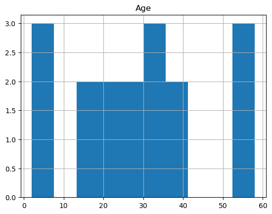

```python
# # Pandas also allow us to plot values directly.
# # Let's plot a histogram of the age of the passengers
# # pandas can create plots using a package called matplotlib
# # (matplotlib must be installed in your environment)
data.hist(column='Age')
```

For accessing a specific value of a column you can you use the at[] property or the get() method, like this:

```
>>> data.at[0, 'Age']
22
>>> data.get('Age')
# the entire column
```

```python
data.at[0, 'Age']
```

```
np.float64(22.0)
```

```python
data.get('Age')
```

```
0     22.0
1     38.0
2     26.0
3     35.0
4     35.0
5      NaN
6     54.0
7      2.0
8     27.0
9     14.0
10     4.0
11    58.0
12    20.0
13    39.0
14    14.0
15    55.0
16     2.0
17     NaN
18    31.0
19     NaN
Name: Age, dtype: float64
```